# Supplemental code file for manuscript titled: Variable gene expression and parasite load predict treatment outcome in cutaneous leishmaniasis

Camila Farias Amorim, Fernanda O. Novais, Ba T. Nguyen, Ana M. Misic, Lucas P. Carvalho, Edgar M. Carvalho, Daniel P. Beiting*, Phillip Scott

produced on *2019-08-22

# 1 Background

The code below shows how raw data was processed, mapped, and analyzed to identify potential biomarkers for treatment outcome in Cutaneous Leishmaniasis. This markdown report is configured to be compiled as a PDF, but if the yaml header above is replaced with the header in the `html_yaml.txt’ located in the same directory as this markdown document, then it can be compiled as an HTML file.

# 2 Reproducibility and accessibility

Raw fastq files are available from the Gene Expression Omnibus, under accession GSE127831, but are not needed for reproducing the analysis. Findings from our study were validated using a second publicly available dataset obtained from the Sequence Read Archive under bioproject PRJNA307599, which was described previously in [Christensen et al, PLOS NTD, 2016](https://www.ncbi.nlm.nih.gov/pubmed/27631090). Note that 6 samples from this bioproject (SRR7275002, SRR7275003, SRR7275004, SRR7275005, SRR7275006, SRR7275007) are actually from a separate study of L. amazonensis and disseminated cutaneous leishmaniasis, and therefore were exlcuded from this analysis. In addition, 1 sample (SRR3162874) from Christensen et al., had no information available for treatment outcome, and therefore was also exclued from the study. Prealigned data and all code used in this analysis, including the Rmarkdown document used to compile this supplementary code file, are all available on GitHub **[here](https://github.com/dpbisme/Amorim_CutaneousLeish_biomarkers)**. The Github version of this document reflects the most up-to-date and comprehensive analysis, and as such it may differ slightly from the one included as a supplementary file in the manuscript. Once this GitHub repo has been downloaded, navigate to `/Amorim_CutaneousLeish_biomarkers/ANALYSIS/code` to find the Rmarkdown document as well as an RProject file.

# 3 R packages used for this analysis

```r
library(tidyverse)
library(ggthemes)
library(reshape2)
library(edgeR)
library(patchwork)
library(vegan)
library(DT)
library(tximport)
library(gplots)
library(FinCal)
library(ggrepel)
library(gt)
library(ggExtra)
library(EnsDb.Hsapiens.v86)
library(stringr)
library(cowplot)
library(ggpubr)
```

# 4 Preprocessing of raw reads

## 4.1 mapping reads to the human transcriptome

Quality control of raw reads was carried out using [fastqc](https://www.bioinformatics.babraham.ac.uk/projects/fastqc/). Raw reads were mapped to the *Homo sapiens* reference transcriptome available on Ensembl here using [Kallisto](https://pachterlab.github.io/kallisto/), version 0.46. The quality of raw reads, as well as the results of Kallisto mapping were summarized using [multiqc](https://multiqc.info/). The resulting multiqc report can be found in the [github project repo](https://github.com/dpbisme/Amorim_CutaneousLeish_biomarkers) in the `QA` directory. Due to size limitations imposed by GitHub, neither the raw fastq files, nor the reference fasta file used for read mapping could be stored in the GitHub repo.

```bash
# build index from reference fasta from Ensembl Homo sapiens transcriptome
kallisto index -i Homo_sapiens.GRCh38.cdna.all.Index Homo_sapiens.GRCh38.cdna.all.fa

# Map reads to the indexed reference transcriptome for HOST
# first the healthy subjects (HS)
kallisto quant -i Homo_sapiens.GRCh38.cdna.all.Index -o host_HS01 -t 24 -b 60 --single -l 250 -s 30 HS1.fastq.gz &> host_HS01.log
kallisto quant -i Homo_sapiens.GRCh38.cdna.all.Index -o host_HS02 -t 24 -b 60 --single -l 250 -s 30 HS2.fastq.gz &> host_HS02.log
kallisto quant -i Homo_sapiens.GRCh38.cdna.all.Index -o host_HS03 -t 24 -b 60 --single -l 250 -s 30 HS3.fastq.gz &> host_HS03.log
kallisto quant -i Homo_sapiens.GRCh38.cdna.all.Index -o host_HS04 -t 24 -b 60 --single -l 250 -s 30 HS4.fastq.gz &> host_HS04.log
kallisto quant -i Homo_sapiens.GRCh38.cdna.all.Index -o host_HS05 -t 24 -b 60 --single -l 250 -s 30 HS5.fastq.gz &> host_HS05.log
kallisto quant -i Homo_sapiens.GRCh38.cdna.all.Index -o host_HS06 -t 24 -b 60 --single -l 250 -s 30 HS6.fastq.gz &> host_HS06.log
kallisto quant -i Homo_sapiens.GRCh38.cdna.all.Index -o host_HS07 -t 24 -b 60 --single -l 250 -s 30 HS7.fastq.gz &> host_HS07.log
# then the cutaneous leishmaniasis (CL) patients
kallisto quant -i Homo_sapiens.GRCh38.cdna.all.Index -o host_CL01 -t 24 -b 60 --single -l 250 -s 30 CL1.fastq.gz &> host_CL01.log
kallisto quant -i Homo_sapiens.GRCh38.cdna.all.Index -o host_CL02 -t 24 -b 60 --single -l 250 -s 30 CL2.fastq.gz &> host_CL02.log
kallisto quant -i Homo_sapiens.GRCh38.cdna.all.Index -o host_CL03 -t 24 -b 60 --single -l 250 -s 30 CL3.fastq.gz &> host_CL03.log
kallisto quant -i Homo_sapiens.GRCh38.cdna.all.Index -o host_CL04 -t 24 -b 60 --single -l 250 -s 30 CL4.fastq.gz &> host_CL04.log
kallisto quant -i Homo_sapiens.GRCh38.cdna.all.Index -o host_CL05 -t 24 -b 60 --single -l 250 -s 30 CL5.fastq.gz &> host_CL05.log
kallisto quant -i Homo_sapiens.GRCh38.cdna.all.Index -o host_CL06 -t 24 -b 60 --single -l 250 -s 30 CL6.fastq.gz &> host_CL06.log
kallisto quant -i Homo_sapiens.GRCh38.cdna.all.Index -o host_CL07 -t 24 -b 60 --single -l 250 -s 30 CL7.fastq.gz &> host_CL07.log
kallisto quant -i Homo_sapiens.GRCh38.cdna.all.Index -o host_CL08 -t 24 -b 60 --single -l 250 -s 30 CL8.fastq.gz &> host_CL08.log
kallisto quant -i Homo_sapiens.GRCh38.cdna.all.Index -o host_CL09 -t 24 -b 60 --single -l 250 -s 30 CL9.fastq.gz &> host_CL09.log
kallisto quant -i Homo_sapiens.GRCh38.cdna.all.Index -o host_CL10 -t 24 -b 60 --single -l 250 -s 30 CL10.fastq.gz &> host_CL10.log
kallisto quant -i Homo_sapiens.GRCh38.cdna.all.Index -o host_CL11 -t 24 -b 60 --single -l 250 -s 30 CL11.fastq.gz &> host_CL11.log
kallisto quant -i Homo_sapiens.GRCh38.cdna.all.Index -o host_CL12 -t 24 -b 60 --single -l 250 -s 30 CL12.fastq.gz &> host_CL12.log
kallisto quant -i Homo_sapiens.GRCh38.cdna.all.Index -o host_CL13 -t 24 -b 60 --single -l 250 -s 30 CL13.fastq.gz &> host_CL13.log
kallisto quant -i Homo_sapiens.GRCh38.cdna.all.Index -o host_CL14 -t 24 -b 60 --single -l 250 -s 30 CL14.fastq.gz &> host_CL14.log
kallisto quant -i Homo_sapiens.GRCh38.cdna.all.Index -o host_CL15 -t 24 -b 60 --single -l 250 -s 30 CL15.fastq.gz &> host_CL15.log
kallisto quant -i Homo_sapiens.GRCh38.cdna.all.Index -o host_CL16 -t 24 -b 60 --single -l 250 -s 30 CL16.fastq.gz &> host_CL16.log
kallisto quant -i Homo_sapiens.GRCh38.cdna.all.Index -o host_CL17 -t 24 -b 60 --single -l 250 -s 30 CL17.fastq.gz &> host_CL17.log
kallisto quant -i Homo_sapiens.GRCh38.cdna.all.Index -o host_CL18 -t 24 -b 60 --single -l 250 -s 30 CL18.fastq.gz &> host_CL18.log
kallisto quant -i Homo_sapiens.GRCh38.cdna.all.Index -o host_CL19 -t 24 -b 60 --single -l 250 -s 30 CL19.fastq.gz &> host_CL19.log
kallisto quant -i Homo_sapiens.GRCh38.cdna.all.Index -o host_CL20 -t 24 -b 60 --single -l 250 -s 30 CL20.fastq.gz &> host_CL20.log
kallisto quant -i Homo_sapiens.GRCh38.cdna.all.Index -o host_CL21 -t 24 -b 60 --single -l 250 -s 30 CL21.fastq.gz &> host_CL21.log
```

# 5 Using R/bioconductor to import RNAseq data

## 5.1 Sample info -

```r
import <- read_tsv("studydesign.txt")
import %>% dplyr::filter(disease == "cutaneous") %>%
  dplyr::select(-2) %>%  gt() %>%
  tab_header(title = md("Clinical metadata from patients with cutaneous leishmaniasis (CL)"),
             subtitle = md("`(n=21)`")) %>%  cols_align(align = "center", columns = TRUE)
```

Clinical metadata from patients with cutaneous leishmaniasis (CL)

`(n=21)`

| sample | treatment_outcome | age_(years) | sex | DTH_(mm2) | lesion_size_(mm2) | Time_to_cure_(days) |
| --- | --- | --- | --- | --- | --- | --- |
| host_CL01 | failure | 35 | F | 255 | 79 | 150 |
| host_CL02 | failure | 21 | M | 228 | 613 | 130 |
| host_CL03 | failure | 29 | M | 180 | 393 | 150 |
| host_CL04 | cure | 37 | M | 300 | 19 | 40 |
| host_CL05 | cure | 50 | M | 272 | 212 | 80 |
| host_CL06 | cure | 26 | F | 285 | 102 | 90 |
| host_CL07 | cure | 28 | F | 272 | 163 | 45 |
| host_CL08 | cure | 63 | M | 196 | 214 | 62 |
| host_CL09 | cure | 59 | M | 255 | 267 | 70 |
| host_CL10 | cure | 22 | M | 255 | 657 | 75 |
| host_CL11 | failure | 49 | M | 240 | 13 | 140 |
| host_CL12 | cure | 42 | M | 225 | 141 | 54 |
| host_CL13 | cure | 69 | M | 150 | 177 | 60 |
| host_CL14 | cure | 19 | M | 208 | 377 | 45 |
| host_CL15 | failure | 18 | M | 130 | 151 | 150 |
| host_CL16 | failure | 46 | M | 150 | 431 | 135 |
| host_CL17 | cure | 35 | M | 270 | 20 | 90 |
| host_CL18 | failure | 51 | M | 225 | 636 | 203 |
| host_CL19 | cure | 25 | M | 180 | 118 | 60 |
| host_CL20 | cure | 20 | F | 100 | 63 | 80 |
| host_CL21 | cure | 55 | M | 1085 | 1237 | 70 |

```r
targets.lesion <- import
targets.onlypatients <- targets.lesion[8:28,] # only CL lesions (n=21)

# Making factors that will be used for pairwise comparisons:
# HS vs. CL lesions as a factor:
disease.lesion <- factor(targets.lesion$disease)
# Cure vs. Failure lesions as a factor:
treatment.lesion <- factor(targets.onlypatients$treatment_outcome)
```

## 5.2 Annotation

The [tximport](https://bioconductor.org/packages/release/bioc/html/tximport.html) package was used to read Kallisto outputs into R environment.

```r
# capturing Ensembl transcript IDs (tx) and gene symbols ("gene_name") from EnsDb.Hsapiens.v86 annotation package
Tx <- as.data.frame(transcripts(EnsDb.Hsapiens.v86,
                                columns=c(listColumns(EnsDb.Hsapiens.v86, "tx"),
                                          "gene_name")))

Tx <- dplyr::rename(Tx, target_id = tx_id)
row.names(Tx) <- NULL
Tx <- Tx[,c(6,12)]

# getting file paths for Kallisto outputs
paths.all <- file.path("../readMapping/human", targets.lesion$sample, "abundance.h5")
paths.patients <- file.path("../readMapping/human", targets.onlypatients$sample, "abundance.h5")

# importing .h5 Kallisto data and collapsing transcript-level data to genes
Txi.lesion.coding <- tximport(paths.all,
                              type = "kallisto",
                              tx2gene = Tx,
                              txOut = FALSE,
                              ignoreTxVersion = TRUE,
                              countsFromAbundance = "lengthScaledTPM")

# importing againg, but this time just the CL patients
Txi.lesion.coding.onlypatients <- tximport(paths.patients,
                                           type = "kallisto",
                                           tx2gene = Tx,
                                           txOut = FALSE,
                                           ignoreTxVersion = TRUE,
                                           countsFromAbundance = "lengthScaledTPM")
```

# 6 Identifying host gene expression associated with treatment failure

Gene-level counts were converted to counts per million (CPM), filtered to keep only genes with >1 CPM in >= 7 samples, and then normalized using the Trimmed Mean of M-values ([TMM method](https://genomebiology.biomedcentral.com/articles/10.1186/gb-2010-11-3-r25)) in the [EdgeR](https://bioconductor.org/packages/release/bioc/html/edgeR.html) package.

## 6.1 filtering and normalization

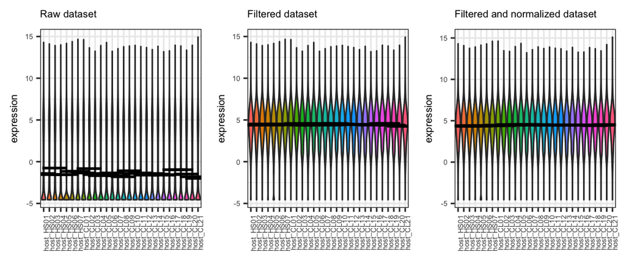

```r
# First make a DGEList from the counts:
Txi.lesion.coding.DGEList <- DGEList(Txi.lesion.coding$counts)
colnames(Txi.lesion.coding.DGEList$counts) <- targets.lesion$sample
colnames(Txi.lesion.coding$counts) <- targets.lesion$sample
#write.table(Txi.lesion.coding$counts, "Amorim_GEO_raw.txt", sep = "\t", quote = FALSE)

Txi.lesion.coding.DGEList.OP <- DGEList(Txi.lesion.coding.onlypatients$counts)
colnames(Txi.lesion.coding.DGEList.OP) <- targets.onlypatients$sample

# Convert to counts per million:
Txi.lesion.coding.DGEList.cpm <- edgeR::cpm(Txi.lesion.coding.DGEList, log = TRUE)
Txi.lesion.coding.DGEList.OP.cpm <- edgeR::cpm(Txi.lesion.coding.DGEList.OP, log = TRUE)

keepers.coding <- rowSums(Txi.lesion.coding.DGEList.cpm>1)>=7
keepers.coding.OP <- rowSums(Txi.lesion.coding.DGEList.OP.cpm>1)>=7

Txi.lesion.coding.DGEList.filtered <- Txi.lesion.coding.DGEList[keepers.coding,]
Txi.lesion.coding.DGEList.OP.filtered <- Txi.lesion.coding.DGEList.OP[keepers.coding.OP,]

# convert back to cpm:
Txi.lesion.coding.DGEList.LogCPM.filtered <- edgeR::cpm(Txi.lesion.coding.DGEList.filtered,
                                                 log=TRUE)
Txi.lesion.coding.DGEList.LogCPM.OP.filtered <- edgeR::cpm(Txi.lesion.coding.DGEList.OP.filtered,
                                                    log=TRUE)

# Normalizing data:
calcNorm1 <- calcNormFactors(Txi.lesion.coding.DGEList.filtered, method = "TMM")
calcNorm2 <- calcNormFactors(Txi.lesion.coding.DGEList.OP.filtered, method = "TMM")

Txi.lesion.coding.DGEList.LogCPM.filtered.norm <- edgeR::cpm(calcNorm1, log=TRUE)
colnames(Txi.lesion.coding.DGEList.LogCPM.filtered.norm) <- targets.lesion$sample
Txi.lesion.coding.DGEList.OP.LogCPM.filtered.norm <- edgeR::cpm(calcNorm2, log=TRUE)
colnames(Txi.lesion.coding.DGEList.OP.LogCPM.filtered.norm) <- targets.onlypatients$sample
# Raw dataset:
V1 <- as.data.frame(Txi.lesion.coding.DGEList.cpm)
colnames(V1) <- targets.lesion$sample
V1 <- melt(V1)
colnames(V1) <- c("sample","expression")

# Filtered dataset:
V1.1 <- as.data.frame(Txi.lesion.coding.DGEList.LogCPM.filtered)
colnames(V1.1) <- targets.lesion$sample
V1.1 <- melt(V1.1)
colnames(V1.1) <- c("sample","expression")

# Filtered-normalized dataset:
V1.1.1 <- as.data.frame(Txi.lesion.coding.DGEList.LogCPM.filtered.norm)
colnames(V1.1.1) <- targets.lesion$sample
V1.1.1 <- melt(V1.1.1)
colnames(V1.1.1) <- c("sample","expression")

# plotting:
ggplot(V1, aes(x=sample, y=expression, fill=sample)) +
  geom_violin(trim = TRUE, show.legend = TRUE) +
  stat_summary(fun.y = "median", geom = "point", shape = 95, size = 10, color = "black") +
  theme_bw() +
  theme(legend.position = "none", axis.title=element_text(size=7),
        axis.title.x=element_blank(), axis.text=element_text(size=5),
        axis.text.x = element_text(angle = 90, hjust = 1),
        plot.title = element_text(size = 7)) +
  ggtitle("Raw dataset") +
ggplot(V1.1, aes(x=sample, y=expression, fill=sample)) +
  geom_violin(trim = TRUE, show.legend = TRUE) +
  stat_summary(fun.y = "median", geom = "point", shape = 95, size = 10, color = "black") +
  theme_bw() +
  theme(legend.position = "none", axis.title=element_text(size=7),
        axis.title.x=element_blank(), axis.text=element_text(size=5),
        axis.text.x = element_text(angle = 90, hjust = 1),
        plot.title = element_text(size = 7)) +
  ggtitle("Filtered dataset") +
ggplot(V1.1.1, aes(x=sample, y=expression, fill=sample)) +
  geom_violin(trim = TRUE, show.legend = TRUE) +
  stat_summary(fun.y = "median", geom = "point", shape = 95, size = 10, color = "black") +
  theme_bw() +
  theme(legend.position = "none", axis.title=element_text(size=7),
        axis.title.x=element_blank(), axis.text=element_text(size=5),
        axis.text.x = element_text(angle = 90, hjust = 1),
        plot.title = element_text(size = 7)) +
  ggtitle("Filtered and normalized dataset")
```

## 6.2 unfiltered data

In this session we are creating a normalized dataset with gene counts (in counts per million, CPM) including all the genes aligned to the human reference (not filtering the dataset).  
The object **CPM_normData_notfiltered_OP** will be used for:  
1) perform differential gene expression analysis between Failure vs. Cure patients to obtain genes with significant P. values and relative fold changes ; 2) the *Variability* and *Treatment outcome* analysis;  
3) as dataframe to make plots of gene expression in GraphPad Prism.

```r
DataNotFiltered_Norm_OP <- calcNormFactors(Txi.lesion.coding.DGEList[,8:28],
                                           method = "TMM")
DataNotFiltered_Norm_log2CPM_OP <- edgeR::cpm(DataNotFiltered_Norm_OP, log=TRUE)
colnames(DataNotFiltered_Norm_log2CPM_OP) <- targets.onlypatients$sample
CPM_normData_notfiltered_OP <- 2^(DataNotFiltered_Norm_log2CPM_OP)
#write.table(Txi.lesion.coding$counts, "Amorim_GEO_raw.txt", sep = "\t", quote = FALSE)

# Including all the individuals (HS and CL patients) for public domain submission:
DataNotFiltered_Norm <- calcNormFactors(Txi.lesion.coding.DGEList, method = "TMM")
DataNotFiltered_Norm_log2CPM <- edgeR::cpm(DataNotFiltered_Norm, log=TRUE)
colnames(DataNotFiltered_Norm_log2CPM) <- targets.lesion$sample
CPM_normData_notfiltered <- 2^(DataNotFiltered_Norm_log2CPM)
#write.table(DataNotFiltered_Norm_log2CPM, "Amorim_GEO_normalized.txt", sep = "\t", quote = FALSE)
```

# 7 Exploratory analysis

## 7.1 PCA comparing infected to naive -

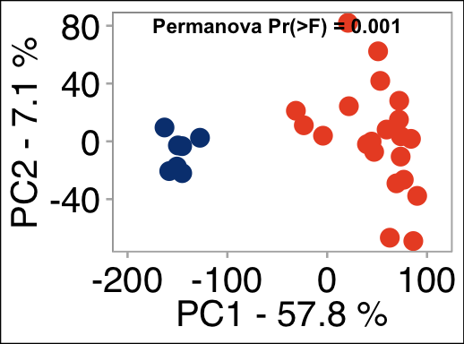

```r
pca.res <- prcomp(t(Txi.lesion.coding.DGEList.LogCPM.filtered.norm), scale.=F, retx=T)
pc.var <- pca.res$sdev^2
pc.per <- round(pc.var/sum(pc.var)*100, 1)
data.frame <- as.data.frame(pca.res$x)

# Calculate distance between samples by permanova:
allsamples.dist <- vegdist(t(2^Txi.lesion.coding.DGEList.LogCPM.filtered.norm),
                           method = "bray")

vegan <- adonis2(allsamples.dist~targets.lesion$disease,
        data=targets.lesion,
        permutations = 999, method="bray")

ggplot(data.frame, aes(x=PC1, y=PC2, color=factor(targets.lesion$disease))) +
  geom_point(size=5, shape=20) +
  theme_calc() +
  theme(panel.grid.major = element_blank(), panel.grid.minor = element_blank(),
        axis.text.x = element_text(size = 15, vjust = 0.5),
        axis.text.y = element_text(size = 15), axis.title = element_text(size = 15),
        legend.position="none") +
  scale_color_manual(values = c("#073F80","#EB512C")) +
  annotate("text", x=-50, y=80, label=paste("Permanova Pr(>F) =",
                                            vegan[1,5]), size=3, fontface="bold") +
  xlab(paste("PC1 -",pc.per[1],"%")) +
  ylab(paste("PC2 -",pc.per[2],"%")) +
  xlim(-200,110)
```

# 8 Differential gene expression analysis (DGE analysis)

```r
# Model matrices:
# CL lesions vs. HS:
design.lesion <- model.matrix(~0 + disease.lesion)
colnames(design.lesion) <- levels(disease.lesion)

# Failure vs. Cure:
design.lesion.treatment <- model.matrix(~0 + treatment.lesion)
colnames(design.lesion.treatment) <- levels(treatment.lesion)

myDGEList.lesion.coding <- DGEList(calcNorm1$counts)
myDGEList.OP.NotFil <- DGEList(CPM_normData_notfiltered_OP)

# Model mean-variance trend and fit linear model to data.
# Use VOOM function from Limma package to model the mean-variance relationship
normData.lesion.coding <- voom(myDGEList.lesion.coding, design.lesion)
normData.OP.NotFil <- voom(myDGEList.OP.NotFil, design.lesion.treatment)

colnames(normData.lesion.coding) <- targets.lesion$sample
colnames(normData.OP.NotFil) <- targets.onlypatients$sample

# fit a linear model to your data
fit.lesion.coding <- lmFit(normData.lesion.coding, design.lesion)
fit.lesion.coding.treatment <- lmFit(normData.OP.NotFil, design.lesion.treatment)

# contrast matrix
contrast.matrix.lesion <- makeContrasts(CL.vs.CON = cutaneous - control,
                                        levels=design.lesion)
contrast.matrix.lesion.treat <- makeContrasts(failure.vs.cure = failure - cure,
                                              levels=design.lesion.treatment)

# extract the linear model fit
fits.lesion.coding <- contrasts.fit(fit.lesion.coding,
                                    contrast.matrix.lesion)
fits.lesion.coding.treat <- contrasts.fit(fit.lesion.coding.treatment,
                                          contrast.matrix.lesion.treat)

# get bayesian stats for your linear model fit
ebFit.lesion.coding <- eBayes(fits.lesion.coding)
ebFit.lesion.coding.treat <- eBayes(fits.lesion.coding.treat)

# TopTable ----
allHits.lesion.coding <- topTable(ebFit.lesion.coding,
                                  adjust ="BH", coef=1,
                                  number=34935, sort.by="logFC")
allHits.lesion.coding.treat <- topTable(ebFit.lesion.coding.treat,
                                        adjust ="BH", coef=1,
                                        number=34776, sort.by="logFC")
myTopHits <- rownames_to_column(allHits.lesion.coding, "geneID")
myTopHits.treat <- rownames_to_column(allHits.lesion.coding.treat, "geneID")

# mutate the format of numeric values:
myTopHits <- mutate(myTopHits, log10Pval = round(-log10(adj.P.Val),2),
                    adj.P.Val = round(adj.P.Val, 2),
                    B = round(B, 2),
                    AveExpr = round(AveExpr, 2),
                    t = round(t, 2),
                    logFC = round(logFC, 2),
                    geneID = geneID)

myTopHits.treat <- mutate(myTopHits.treat, log10Pval = round(-log10(adj.P.Val),2),
                    adj.P.Val = round(adj.P.Val, 2),
                    B = round(B, 2),
                    AveExpr = round(AveExpr, 2),
                    t = round(t, 2),
                    logFC = round(logFC, 2),
                    geneID = geneID)
#save(myTopHits, file = "myTopHits")
#save(myTopHits.treat, file = "myTopHits.treat")
```

## 8.1 Volcano Plot for CL vs. HS -

In this session, we visualize in a volcano plot the upregulated (orange) and downregulated (blue) genes in cutaneous leishmaniasis (CL) lesions relative to skin from healthy subjects (HS).

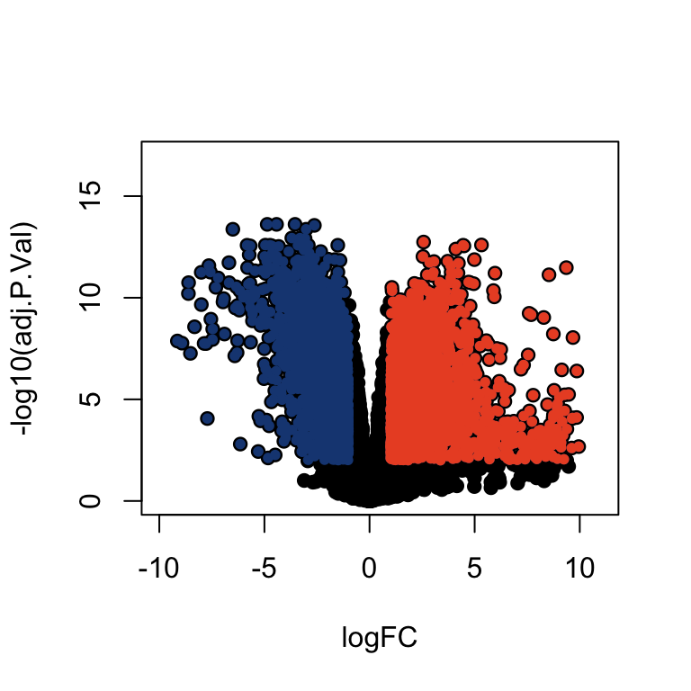

```r
with(allHits.lesion.coding,
     plot(logFC, -log10(adj.P.Val), pch=19, cex=1,
          xlim=c(-10, 11), ylim=c(0, 17), main=""))
with(subset(allHits.lesion.coding, adj.P.Val<0.01 & abs(logFC)>1),
     points(logFC, -log10(adj.P.Val), pch=20, col="#1A4682"))
with(subset(allHits.lesion.coding, adj.P.Val<0.01 & (logFC)>1),
     points(logFC, -log10(adj.P.Val), pch=20, col="#EB522C"))
```

## 8.2 Top 100 upregulated genes in CL vs. HS -

In this session, the top 100 upregulate genes in CL lesions relative to HS are represented in a heatmap.

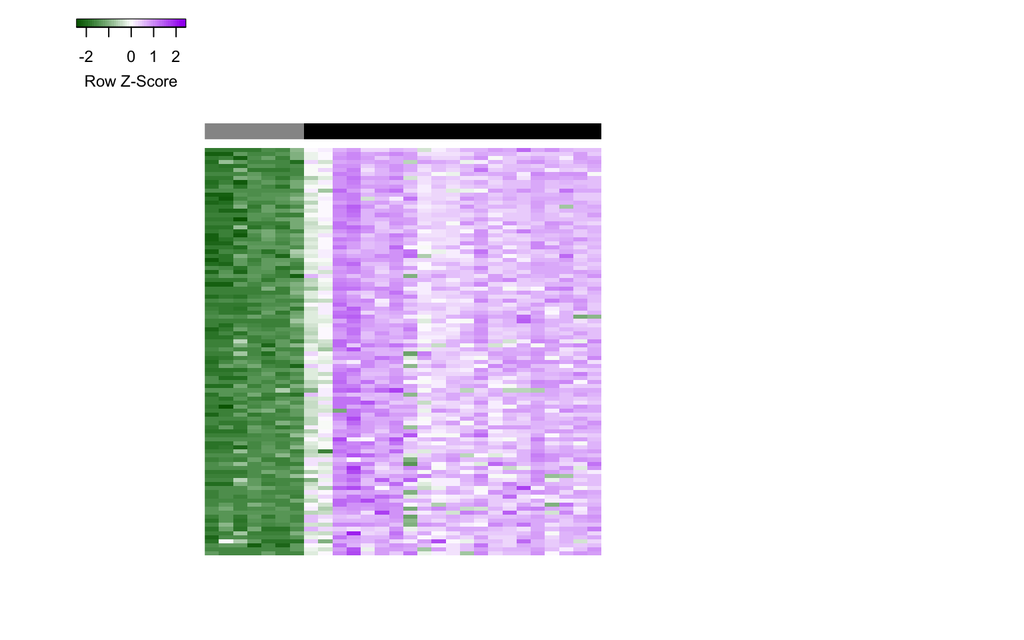

```r
color.map1 <- function(disease.lesion) { if (disease.lesion=="control") "#969696"
  else "#000000"} # coloring CL vs. HS
color.map1 <- unlist(lapply(disease.lesion, color.map1))

sortedupFC <- myTopHits[order(-myTopHits$logFC),]
rownames(sortedupFC) <- sortedupFC$geneID
sorteduptop <- sortedupFC[-grep("IG", sortedupFC$geneID),]

#Top 100 gene supregulated:
top100up <- sortedupFC[1:100,]$geneID
TopUPtable100 <- Txi.lesion.coding.DGEList.LogCPM.filtered.norm[c(top100up),]
TopUPmatrixcoding100 <- as.matrix(TopUPtable100)

colormapX <- colorRampPalette(colors=c("dark green","white","purple"))(50)

HeatmapUP100 <- heatmap.2(TopUPmatrixcoding100,
                          ColSideColors = color.map1,
                          scale = "row", key=TRUE,
                          keysize = 1, key.title = NA,
                          col=colormapX, dendrogram = "none", Rowv = F,
                          margins=c(5,25),
                          labCol = NA, labRow = NA,
                          main = "",
                          density.info="none", trace="none",
                          cexRow=0.8, cexCol=1)
```

# 9 Identification of ViTALs

Using Coefficient of Variation (cV) of gene expression across CL patients to identify Transcripts Associated with Leishmaniasis (ViTALs)

## 9.1 Expression fold change vs. Coefficient of Variation -

Here, we explored the variability in gene expression between CL lesions. The strategy was to calculate the *Coefficient of Variation (cV)* for all the genes upregulated in the lesions. In this way, we can observe which gene had high expression variability between CL lesions (high variable genes, HVGenes).

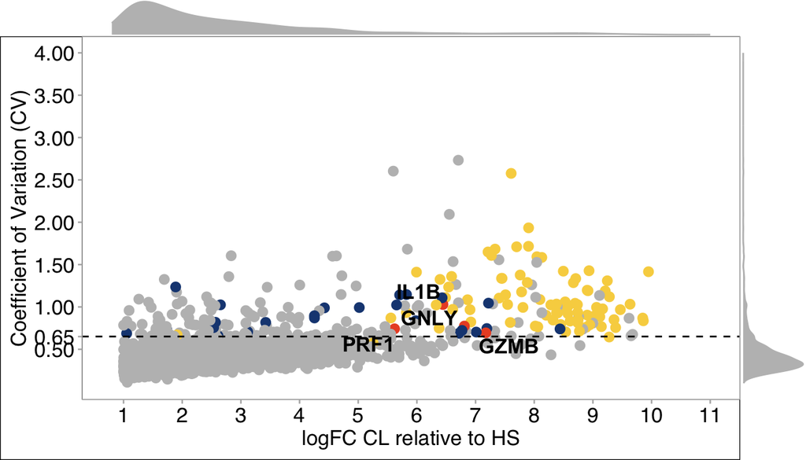

```r
# Filtering all the genes that were upregulated CL lesions vs. HS with
# more than FC = 2 and a FDR<0.01:
UpregulatedInCL <- subset(allHits.lesion.coding, logFC > 1 & adj.P.Val < 0.01)

# getting the expression levels of these genes for each CL sample:
UpregulatedInCL_names <- rownames(UpregulatedInCL) # names of upregulated genes in CL
all_genes_test2 <- CPM_normData_notfiltered_OP[UpregulatedInCL_names,]

# calculate standard deviation (sd) and mean for upregulated genes in CL lesions
mean_allgenes2 <- rowMeans(all_genes_test2)
sd_test_allgenes2 <- transform(all_genes_test2, SD=apply(all_genes_test2,1, sd,
                                                         na.rm = TRUE))
SDs_allgenes2 <- sd_test_allgenes2$SD
genes_all2 <- rownames(sd_test_allgenes2)

# calculating the cV:
MeanSD_allgenes2 <- cbind(genes_all2, mean_allgenes2, SDs_allgenes2)
CV_allgenes2 <- coefficient.variation(SDs_allgenes2, mean_allgenes2)

# making a dataframe with gene symbols, sd, mean and cV:
allgenes_stats <- cbind(genes_all2, mean_allgenes2, SDs_allgenes2, CV_allgenes2)

# select and filter genes with increased expression variability between CL lesions:
CV_upreg_varies <- subset(allgenes_stats, CV_allgenes2 > 0.6506) # high cV (250 HVGenes)
#CV_upreg_notvaries <- subset(allgenes_stats, CV_allgenes2 < 0.6506)# low cV

# Plot upregulated genes in CL, according to cV and FC (log2)
SD_CV.pre <- allgenes_stats[,c(-1)] # removing a colunm with gene names

# getting FC from limma DGE analyis Cl vs. HS:
tophits_genes <- allHits.lesion.coding[UpregulatedInCL_names,]

SD_CV <- cbind(tophits_genes, SD_CV.pre)
SD_CV$CV_allgenes2 <- as.numeric(as.character(SD_CV$CV_allgenes2))
SD_CV$SDs_allgenes2 <- as.numeric(as.character(SD_CV$SDs_allgenes2))
SD_CV$genes <- rownames(SD_CV)
SD_CV$genes2 <- SD_CV$genes

# Important: the gene symbols from high varible genes (250 genes) were used to evaluate
# by gene ontology (using DAVID website) the pathways enriched and associated with high
# variability.
# The pathways enriched (FDR<0.01) were:
# Cluster 1: B cell responses
# Cluster 2: chemotaxis
# Cluster 3: cytotoxic granules + IL1B
# Genes contained in these pathways were:
cluster1 <- c("IGHA1","IGHA2","IGHG1","IGHG2","IGHG3","IGHG4","IGHM","IGHV1-18","IGHV1-2",
              "IGHV1-24","IGHV1-46","IGHV1-58","IGHV1OR16-1","IGHV2-70","IGHV3-11",
              "IGHV3-15","IGHV3-21","IGHV3-23","IGHV3-33","IGHV3-43","IGHV3-48",
              "IGHV3-49","IGHV3-53","IGHV3-62","IGHV3-64","IGHV3-7","IGHV3-72","IGHV3-73",
              "IGHV3-74","IGHV3OR16-9","IGHV4-28","IGHV4-31","IGHV4-39","IGHV4-59",
              "IGHV5-51","IGHV6-1","IGKC","IGKV1-12","IGKV1-16","IGKV1-17","IGKV1-27",
              "IGKV1-39","IGKV1-5","IGKV1-6","IGKV1-9","IGKV1D-33","IGKV1D-39","IGKV1D-8",
              "IGKV2-24","IGKV2-30","IGKV2D-28","IGKV2D-29","IGKV3-11","IGKV3-15",
              "IGKV3-20","IGKV3D-11","IGKV3D-15","IGKV3D-20","IGKV3D-7","IGKV4-1",
              "IGKV6-21","IGLC1","IGLC2","IGLC3","IGLL5","IGLV1-36","IGLV1-40",
              "IGLV1-44","IGLV3-10","IGLV3-19","IGLV3-25","IGLV3-27","IGLV3-9","IGLV4-69",
              "IGLV5-45","IGLV6-57","IGLV7-43","IGLV7-46","CD79A","CR1","KIR3DL2",
              "KIR2DL4","JCHAIN")
cluster2 <- c("CCL18","CCL20","CCL3","CCL4","CCL8","CXCL1","CXCL11","CXCL13","CXCL2",
              "CXCL3","CXCL6","CXCL8","S100A12","S100A8","S100A9","CSF3R","TREM1",
              "ANXA1","NDP","WISP1","ADCYAP1","BHLHA15","CYR61","GJB2","INHBA","RNASE2")
cluster3 <- c("GZMB","PRF1","GNLY","IL1B")

# make objects and conditions that will be used to annotate the gene symbols in the plots:
mygenes <- SD_CV$genes2 %in% cluster3
SD_CV$genes2[!mygenes] <- NA
SD_CV$genes3 <- SD_CV$genes
cytotoxicity <- SD_CV$genes3 %in% cluster3
Igs <- SD_CV$genes3 %in% cluster1
chemokines <- SD_CV$genes3 %in% cluster2
inflammation <- SD_CV$genes3 %in% c("IL1B")

SD_CV$genes3[cytotoxicity] <- "cytotoxic granules"
SD_CV$genes3[Igs] <- "B cell response (immunoglubulins)"
SD_CV$genes3[chemokines] <- "chemotaxis (chemokines)"
SD_CV$genes3[inflammation] <- "IL1B"
SD_CV$genes3[!cytotoxicity & !Igs & !chemokines] <- "others"

# Variability plot:
ggExtra::ggMarginal(
  ggplot(SD_CV, aes(y=CV_allgenes2, x=logFC, color=SD_CV$genes3)) +
    geom_point(size=2.5) +
    theme_calc() + scale_color_manual(values = c("#F8D34F", # yellow
                                                 "#1A4682", # blue
                                                 "#EB522C", # orange
                                                 "#EB522C", # orange
                                                 "grey")) +
    theme(legend.position="none", axis.title = element_text(size = 13),
          panel.grid.major = element_blank(),
          panel.grid.minor = element_blank(), legend.text = element_text(size = 15),
          axis.text.x=element_text(size=13, colour = "black"),
          axis.text.y = element_text(size=13, colour = "black")) +
    labs(colour="") +
    geom_text_repel(aes(label = genes2),
                    size = 4.5, fontface="bold",colour="black") +
    geom_hline(yintercept = 0.6506, linetype=2) +
    scale_x_continuous(limits=c(0.8,11), breaks = c(1,2,3,4,5,6,7,8,9,10,11)) +
    scale_y_continuous(limits=c(0.1,4), breaks = c(0.5,0.65,1,1.5,2,2.5,3,3.5,4)) +
    xlab("logFC CL relative to HS") +
    ylab("Coefficient of Variation (CV)"),
  type = 'density', margins = 'both', size = 10, col = 'grey', fill = 'grey')
```

# 10 Association of ViTALs with treatment failure

## 10.1 volcano plot of ViTALs -

In this session we identify between the 250 HVGenes which genes were statistically different between Failure vs. Cure patients.

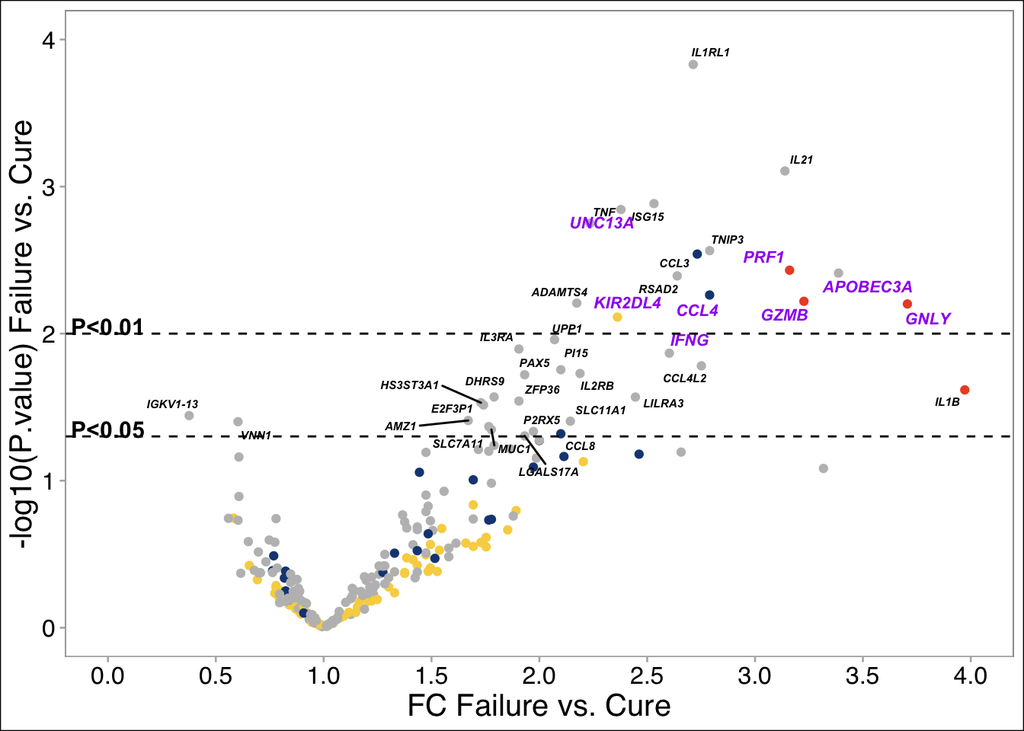

```r
merged1 <- myTopHits.treat # accessing the limma DGE analysis between Failure vs. Cure
rownames(merged1) <- merged1$geneID
merged1 <- merged1[c(rownames(CV_upreg_varies)),]
merged1 <- merged1[,c("geneID","logFC","P.Value", "t")]

# selecting the genes with P.value<0.05 to label them in the plot
sigfailure.pre <- subset(merged1, P.Value < 0.05)
sigfailure <- rownames(sigfailure.pre)

# label genes with P.value<0.5 in the plot.
# also, highlight in the plot the genes also found to be differentially expressed between
# Failure vs. Cure (P.value<0.05) in an independente dataset (2016 dataset).
# Reference: Chirstensen SM et al., 2016
dataset2016 <- c("PRF1","GZMB","GNLY","APOBEC3A","CCL4","KIR2DL4","UNC13A","IFNG")

sigfailure <- sigfailure[!sigfailure %in% dataset2016]
merged1$siginfo <- merged1$geneID
sigfailureX <- merged1$siginfo %in% sigfailure
merged1$siginfo[!sigfailureX] <- NA
merged1$bothdata <- merged1$geneID
bothdataX <- merged1$bothdata %in% dataset2016
merged1$bothdata[!bothdataX] <- NA

# color clusters in the plot:
merged1$geneID2 <- merged1$geneID
cytotoxicity <- merged1$geneID2 %in% cluster3
Igs <- merged1$geneID2 %in% cluster1
chemokines <- merged1$geneID2 %in% cluster2
merged1$geneID2[cytotoxicity] <- "cytotoxic granules"
merged1$geneID2[Igs] <- "B cell response (immunoglubulins)"
merged1$geneID2[chemokines] <- "chemotaxis (chemokines)"
merged1$geneID2[!cytotoxicity & !Igs & !chemokines] <- "others"

# Treatment outcome plot:
ggplot(merged1, aes(x=2^logFC, y=-log10(P.Value),
                    color=merged1$geneID2)) +
  geom_point() +
  theme_calc() + scale_color_manual(values = c("#F8D34F", # yellow
                                               "#1A4682", # blue
                                               "#EB522C", # orange
                                               "grey")) +
  theme(legend.position="none", axis.title = element_text(size = 15),
        panel.grid.major = element_blank(),
        panel.grid.minor = element_blank(), legend.text = element_text(size = 17),
        axis.text.x=element_text(size=12, colour = "black"),
        axis.text.y = element_text(size=12, colour = "black")) +
  labs(size="CV") +
  geom_text_repel(aes(label = siginfo),
                  size = 2,
                  fontface=4,
                  color="black") +
  geom_text_repel(aes(label = bothdata),
                  size = 2.8, fontface=4, color="purple") +
  scale_y_continuous(limits=c(0,4)) +
  scale_x_continuous(limits=c(0,4), breaks = c(0,0.5,1,1.5,2,2.5,3,3.5,4)) +
  geom_hline(yintercept = -log10(0.01), linetype=2) +
  geom_hline(yintercept = -log10(0.05), linetype=2) +
  annotate("text", x=0, y=-log10(0.01)+0.05,
           label=paste("P<0.01"), size=4, fontface="bold") +
  annotate("text", x=0, y=-log10(0.05)+0.05,
           label=paste("P<0.05"), size=4, fontface="bold") +
  xlab("FC Failure vs. Cure") +
  ylab("-log10(P.value) Failure vs. Cure")
```

# 11 Identifying parasite transcripts in patients

## 11.1 host read filtering

Reads mapping to host were removed using [Kneaddata](https://bitbucket.org/biobakery/kneaddata/wiki/Home), which uses Bowtie2 to map reads to the human reference genome. Reads that *did not* map to human were be used for mapping to the parasite reference transcriptome in the next step.

```bash
# first the healthy subjects (HS).
kneaddata -i HS1.fastq.gz -db /data/reference_db/Homo_sapiens/Ensembl/GRCh37/Sequence/Bowtie2Index -o HS1_filtered -t 24
kneaddata -i HS2.fastq.gz -db /data/reference_db/Homo_sapiens/Ensembl/GRCh37/Sequence/Bowtie2Index -o HS2_filtered -t 24
kneaddata -i HS3.fastq.gz -db /data/reference_db/Homo_sapiens/Ensembl/GRCh37/Sequence/Bowtie2Index -o HS3_filtered -t 24
kneaddata -i HS4.fastq.gz -db /data/reference_db/Homo_sapiens/Ensembl/GRCh37/Sequence/Bowtie2Index -o HS4_filtered -t 24
kneaddata -i HS5.fastq.gz -db /data/reference_db/Homo_sapiens/Ensembl/GRCh37/Sequence/Bowtie2Index -o HS5_filtered -t 24
kneaddata -i HS6.fastq.gz -db /data/reference_db/Homo_sapiens/Ensembl/GRCh37/Sequence/Bowtie2Index -o HS6_filtered -t 24
kneaddata -i HS7.fastq.gz -db /data/reference_db/Homo_sapiens/Ensembl/GRCh37/Sequence/Bowtie2Index -o HS7_filtered -t 24

# then the cutaneous leishmaniasis (CL) patients
kneaddata -i CL1.fastq.gz -db /data/reference_db/Homo_sapiens/Ensembl/GRCh37/Sequence/Bowtie2Index -o CL1_filtered -t 24
kneaddata -i CL2.fastq.gz -db /data/reference_db/Homo_sapiens/Ensembl/GRCh37/Sequence/Bowtie2Index -o CL2_filtered -t 24
kneaddata -i CL3.fastq.gz -db /data/reference_db/Homo_sapiens/Ensembl/GRCh37/Sequence/Bowtie2Index -o CL3_filtered -t 24
kneaddata -i CL4.fastq.gz -db /data/reference_db/Homo_sapiens/Ensembl/GRCh37/Sequence/Bowtie2Index -o CL4_filtered -t 24
kneaddata -i CL5.fastq.gz -db /data/reference_db/Homo_sapiens/Ensembl/GRCh37/Sequence/Bowtie2Index -o CL5_filtered -t 24
kneaddata -i CL6.fastq.gz -db /data/reference_db/Homo_sapiens/Ensembl/GRCh37/Sequence/Bowtie2Index -o CL6_filtered -t 24
kneaddata -i CL7.fastq.gz -db /data/reference_db/Homo_sapiens/Ensembl/GRCh37/Sequence/Bowtie2Index -o CL7_filtered -t 24
kneaddata -i CL8.fastq.gz -db /data/reference_db/Homo_sapiens/Ensembl/GRCh37/Sequence/Bowtie2Index -o CL8_filtered -t 24
kneaddata -i CL9.fastq.gz -db /data/reference_db/Homo_sapiens/Ensembl/GRCh37/Sequence/Bowtie2Index -o CL9_filtered -t 24
kneaddata -i CL10.fastq.gz -db /data/reference_db/Homo_sapiens/Ensembl/GRCh37/Sequence/Bowtie2Index -o CL10_filtered -t 24
kneaddata -i CL11.fastq.gz -db /data/reference_db/Homo_sapiens/Ensembl/GRCh37/Sequence/Bowtie2Index -o CL11_filtered -t 24
kneaddata -i CL12.fastq.gz -db /data/reference_db/Homo_sapiens/Ensembl/GRCh37/Sequence/Bowtie2Index -o CL12_filtered -t 24
kneaddata -i CL13.fastq.gz -db /data/reference_db/Homo_sapiens/Ensembl/GRCh37/Sequence/Bowtie2Index -o CL13_filtered -t 24
kneaddata -i CL14.fastq.gz -db /data/reference_db/Homo_sapiens/Ensembl/GRCh37/Sequence/Bowtie2Index -o CL14_filtered -t 24
kneaddata -i CL15.fastq.gz -db /data/reference_db/Homo_sapiens/Ensembl/GRCh37/Sequence/Bowtie2Index -o CL15_filtered -t 24
kneaddata -i CL16.fastq.gz -db /data/reference_db/Homo_sapiens/Ensembl/GRCh37/Sequence/Bowtie2Index -o CL16_filtered -t 24
kneaddata -i CL17.fastq.gz -db /data/reference_db/Homo_sapiens/Ensembl/GRCh37/Sequence/Bowtie2Index -o CL17_filtered -t 24
kneaddata -i CL18.fastq.gz -db /data/reference_db/Homo_sapiens/Ensembl/GRCh37/Sequence/Bowtie2Index -o CL18_filtered -t 24
kneaddata -i CL19.fastq.gz -db /data/reference_db/Homo_sapiens/Ensembl/GRCh37/Sequence/Bowtie2Index -o CL19_filtered -t 24
kneaddata -i CL20.fastq.gz -db /data/reference_db/Homo_sapiens/Ensembl/GRCh37/Sequence/Bowtie2Index -o CL20_filtered -t 24
kneaddata -i CL21.fastq.gz -db /data/reference_db/Homo_sapiens/Ensembl/GRCh37/Sequence/Bowtie2Index -o CL21_filtered -t 24
```

## 11.2 mapping reads to the parasite transcriptome

```bash
# Map reads to the indexed reference transcriptome for PARASITE
# the input for these alignments are the filtered fastq files produced above by Kneaddata.

# build index from reference fasta from Ensembl L. braziliensis transcriptome
kallisto index -i Leishmania_braziliensis_mhom_br_75_m2904.ASM284v2.cdna.all.index Leishmania_braziliensis_mhom_br_75_m2904.ASM284v2.cdna.all.fa

# first the healthy subjects (HS).  These will serve as a negative control for parasite read mapping
kallisto quant -i Leishmania_braziliensis_mhom_br_75_m2904.ASM284v2.cdna.all.index -o parasite_HS01 -t 24 -b 60 --single -l 250 -s 30 HS1_filtered.fastq &> parasite_HS01.log
kallisto quant -i Leishmania_braziliensis_mhom_br_75_m2904.ASM284v2.cdna.all.index -o parasite_HS02 -t 24 -b 60 --single -l 250 -s 30 HS2_filtered.fastq &> parasite_HS02.log
kallisto quant -i Leishmania_braziliensis_mhom_br_75_m2904.ASM284v2.cdna.all.index -o parasite_HS03 -t 24 -b 60 --single -l 250 -s 30 HS3_filtered.fastq &> parasite_HS03.log
kallisto quant -i Leishmania_braziliensis_mhom_br_75_m2904.ASM284v2.cdna.all.index -o parasite_HS04 -t 24 -b 60 --single -l 250 -s 30 HS4_filtered.fastq &> parasite_HS04.log
kallisto quant -i Leishmania_braziliensis_mhom_br_75_m2904.ASM284v2.cdna.all.index -o parasite_HS05 -t 24 -b 60 --single -l 250 -s 30 HS5_filtered.fastq &> parasite_HS05.log
kallisto quant -i Leishmania_braziliensis_mhom_br_75_m2904.ASM284v2.cdna.all.index -o parasite_HS06 -t 24 -b 60 --single -l 250 -s 30 HS6_filtered.fastq &> parasite_HS06.log
kallisto quant -i Leishmania_braziliensis_mhom_br_75_m2904.ASM284v2.cdna.all.index -o parasite_HS07 -t 24 -b 60 --single -l 250 -s 30 HS7_filtered.fastq &> parasite_HS07.log


# then the cutaneous leishmaniasis (CL) patients
kallisto quant -i Leishmania_braziliensis_mhom_br_75_m2904.ASM284v2.cdna.all.index -o parasite_CL01 -t 24 -b 60 --single -l 250 -s 30 CL1_filtered.fastq &> parasite_CL01.log
kallisto quant -i Leishmania_braziliensis_mhom_br_75_m2904.ASM284v2.cdna.all.index -o parasite_CL02 -t 24 -b 60 --single -l 250 -s 30 CL2_filtered.fastq &> parasite_CL02.log
kallisto quant -i Leishmania_braziliensis_mhom_br_75_m2904.ASM284v2.cdna.all.index -o parasite_CL03 -t 24 -b 60 --single -l 250 -s 30 CL3_filtered.fastq &> parasite_CL03.log
kallisto quant -i Leishmania_braziliensis_mhom_br_75_m2904.ASM284v2.cdna.all.index -o parasite_CL04 -t 24 -b 60 --single -l 250 -s 30 CL4_filtered.fastq &> parasite_CL04.log
kallisto quant -i Leishmania_braziliensis_mhom_br_75_m2904.ASM284v2.cdna.all.index -o parasite_CL05 -t 24 -b 60 --single -l 250 -s 30 CL5_filtered.fastq &> parasite_CL05.log
kallisto quant -i Leishmania_braziliensis_mhom_br_75_m2904.ASM284v2.cdna.all.index -o parasite_CL06 -t 24 -b 60 --single -l 250 -s 30 CL6_filtered.fastq &> parasite_CL06.log
kallisto quant -i Leishmania_braziliensis_mhom_br_75_m2904.ASM284v2.cdna.all.index -o parasite_CL07 -t 24 -b 60 --single -l 250 -s 30 CL7_filtered.fastq &> parasite_CL07.log
kallisto quant -i Leishmania_braziliensis_mhom_br_75_m2904.ASM284v2.cdna.all.index -o parasite_CL08 -t 24 -b 60 --single -l 250 -s 30 CL8_filtered.fastq &> parasite_CL08.log
kallisto quant -i Leishmania_braziliensis_mhom_br_75_m2904.ASM284v2.cdna.all.index -o parasite_CL09 -t 24 -b 60 --single -l 250 -s 30 CL9_filtered.fastq &> parasite_CL09.log
kallisto quant -i Leishmania_braziliensis_mhom_br_75_m2904.ASM284v2.cdna.all.index -o parasite_CL10 -t 24 -b 60 --single -l 250 -s 30 CL10_filtered.fastq &> parasite_CL10.log
kallisto quant -i Leishmania_braziliensis_mhom_br_75_m2904.ASM284v2.cdna.all.index -o parasite_CL11 -t 24 -b 60 --single -l 250 -s 30 CL11_filtered.fastq &> parasite_CL11.log
kallisto quant -i Leishmania_braziliensis_mhom_br_75_m2904.ASM284v2.cdna.all.index -o parasite_CL12 -t 24 -b 60 --single -l 250 -s 30 CL12_filtered.fastq &> parasite_CL12.log
kallisto quant -i Leishmania_braziliensis_mhom_br_75_m2904.ASM284v2.cdna.all.index -o parasite_CL13 -t 24 -b 60 --single -l 250 -s 30 CL13_filtered.fastq &> parasite_CL13.log
kallisto quant -i Leishmania_braziliensis_mhom_br_75_m2904.ASM284v2.cdna.all.index -o parasite_CL14 -t 24 -b 60 --single -l 250 -s 30 CL14_filtered.fastq &> parasite_CL14.log
kallisto quant -i Leishmania_braziliensis_mhom_br_75_m2904.ASM284v2.cdna.all.index -o parasite_CL15 -t 24 -b 60 --single -l 250 -s 30 CL15_filtered.fastq &> parasite_CL15.log
kallisto quant -i Leishmania_braziliensis_mhom_br_75_m2904.ASM284v2.cdna.all.index -o parasite_CL16 -t 24 -b 60 --single -l 250 -s 30 CL16_filtered.fastq &> parasite_CL16.log
kallisto quant -i Leishmania_braziliensis_mhom_br_75_m2904.ASM284v2.cdna.all.index -o parasite_CL17 -t 24 -b 60 --single -l 250 -s 30 CL17_filtered.fastq &> parasite_CL17.log
kallisto quant -i Leishmania_braziliensis_mhom_br_75_m2904.ASM284v2.cdna.all.index -o parasite_CL18 -t 24 -b 60 --single -l 250 -s 30 CL18_filtered.fastq &> parasite_CL18.log
kallisto quant -i Leishmania_braziliensis_mhom_br_75_m2904.ASM284v2.cdna.all.index -o parasite_CL19 -t 24 -b 60 --single -l 250 -s 30 CL19_filtered.fastq &> parasite_CL19.log
kallisto quant -i Leishmania_braziliensis_mhom_br_75_m2904.ASM284v2.cdna.all.index -o parasite_CL20 -t 24 -b 60 --single -l 250 -s 30 CL20_filtered.fastq &> parasite_CL20.log
kallisto quant -i Leishmania_braziliensis_mhom_br_75_m2904.ASM284v2.cdna.all.index -o parasite_CL21 -t 24 -b 60 --single -l 250 -s 30 CL21_filtered.fastq &> parasite_CL21.log
```

## 11.3 parasite transcripts in CL vs HS

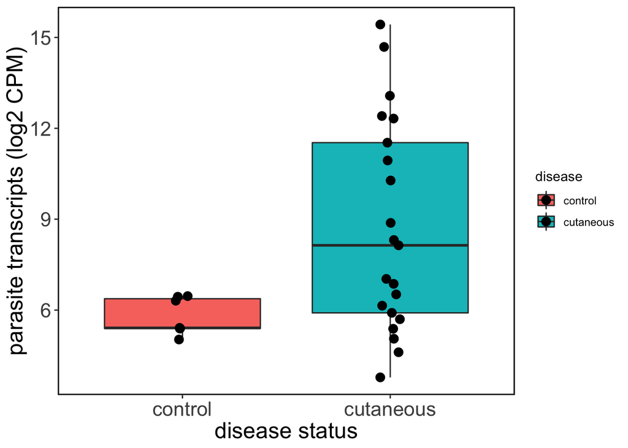

```r
list.patients <- 1:21
list.healthy <- 1:7

list.patients <- str_pad(list.patients, 2, pad = "0")
list.healthy <- str_pad(list.healthy, 2, pad = "0")

paths.patients.parasite <- file.path("../readMapping/Lbraz", c(paste0("parasite_CL", list.patients)), "abundance.h5")
paths.healthy.parasite <- file.path("../readMapping/Lbraz", c(paste0("parasite_HS", list.healthy)), "abundance.h5")

paths.all <- c(paths.healthy.parasite, paths.patients.parasite)

Txi.lesion.all <- tximport(paths.all,
                              type = "kallisto",
                              txOut = TRUE,
                              ignoreTxVersion = TRUE,
                              countsFromAbundance = "lengthScaledTPM")

#number of reads remaining after removing host reads above
librarySize.all <- c(9603863, 6013019, 7269338, 2347419, 641140, 5384651, 6807472, #healthy subjects
                 9243184, 4332726, 11725185, 3494176, 16896230, 16427463, 5035568, 10252676,
                 8794839, 8145232, 6398817, 6467353, 12087118, 10636911, 12100797, 8457067,
                 6116730, 8201034, 12736501, 4582083, 12757299)

librarySize.all <- librarySize.all/1000000

parasiteTx_CPM <- colSums(Txi.lesion.all$counts)/librarySize.all

ggplot(targets.lesion, aes(x=disease, y=log2(parasiteTx_CPM), fill=disease)) +
  geom_boxplot(outlier.shape = NA) +
  labs(y="parasite transcripts (log2 CPM)", x = "disease status") +
  geom_jitter(width = .05, size=3) +
  theme_bw() +
  theme(axis.text=element_text(size=16),
        axis.title=element_text(size=18),
        plot.title = element_text(face="bold"),
        panel.border = element_rect(colour = "black", fill=NA, size=1),
        panel.grid.major = element_blank(),
        panel.grid.minor = element_blank())
```

## 11.4 comparing parasite transcripts with treatment outcome

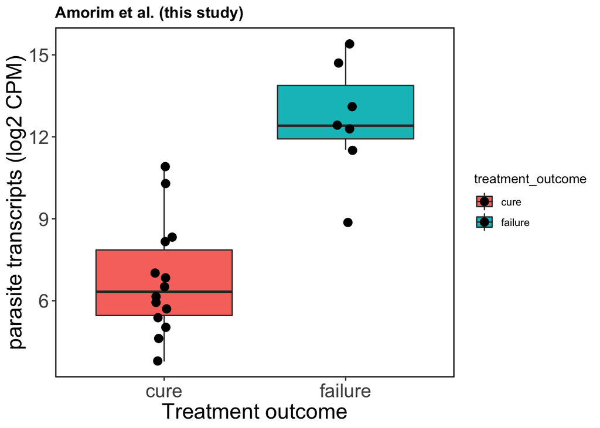

```r
list <- 1:21
list <- str_pad(list, 2, pad = "0")
paths.patients.parasite <- file.path("../readMapping/Lbraz", c(paste0("parasite_CL", list)), "abundance.h5")

Txi.lesion.parasite <- tximport(paths.patients.parasite,
                              type = "kallisto",
                              txOut = TRUE,
                              ignoreTxVersion = TRUE,
                              countsFromAbundance = "lengthScaledTPM")

#modifying the patient-level data to include parasite counts, as well as expresion of selected ViTALs
ViTALs_selected <- Txi.lesion.coding.onlypatients$abundance %>%
  as_tibble(rownames = "geneSymbol") %>%
  dplyr::filter(geneSymbol == "PRF1" | geneSymbol =="GNLY" | geneSymbol == "GZMB" | geneSymbol =="IFNG"
                | geneSymbol == "UNC13A" | geneSymbol =="KIR2DL4" | geneSymbol == "CCL4" | geneSymbol =="APOBEC3A")

geneSymbols_ViTALS_selected <- ViTALs_selected$geneSymbol
ViTALs_selected <- as.data.frame(t(ViTALs_selected[,-1]))
colnames(ViTALs_selected) <- geneSymbols_ViTALS_selected

#number of reads remaining after removing host reads above
librarySize.CL <- c(9243184, 4332726, 11725185, 3494176, 16896230, 16427463, 5035568, 10252676,
                 8794839, 8145232, 6398817, 6467353, 12087118, 10636911, 12100797, 8457067,
                 6116730, 8201034, 12736501, 4582083, 12757299)

librarySize.CL <- librarySize.CL/1000000
parasiteTx_CPM_Amorim <- colSums(Txi.lesion.parasite$counts)/librarySize.CL

targets.onlypatients <- targets.onlypatients %>%
  dplyr::mutate(parasiteTx_CPM_Amorim = parasiteTx_CPM_Amorim) %>%
  dplyr::mutate(PRF1 = ViTALs_selected$PRF1) %>%
  dplyr::mutate(GZMB = ViTALs_selected$GZMB) %>%
  dplyr::mutate(CCL4 = ViTALs_selected$CCL4) %>%
  dplyr::mutate(GNLY = ViTALs_selected$GNLY) %>%
  dplyr::mutate(UNC13A = ViTALs_selected$UNC13A) %>%
  dplyr::mutate(APOBEC3A = ViTALs_selected$APOBEC3A) %>%
  dplyr::mutate(KIR2DL4 = ViTALs_selected$KIR2DL4) %>%
  dplyr::mutate(IFNG = ViTALs_selected$IFNG)

#also storing this plot for use later
p1 <- ggplot(targets.onlypatients, aes(x=treatment_outcome, y=log2(parasiteTx_CPM_Amorim), fill=treatment_outcome)) +
  geom_boxplot(outlier.shape = NA) +
  labs(y="parasite transcripts (log2 CPM)", x = "Treatment outcome",
       title = "Amorim et al. (this study)") +
  geom_jitter(width = .05, size=3) +
  theme_bw() +
  theme(legend.position = "none",
        axis.text=element_text(size=16),
        axis.title=element_text(size=18),
        plot.title = element_text(face="bold"),
        panel.border = element_rect(colour = "black", fill=NA, size=1),
        panel.grid.major = element_blank(),
        panel.grid.minor = element_blank())

ggplot(targets.onlypatients, aes(x=treatment_outcome, y=log2(parasiteTx_CPM_Amorim), fill=treatment_outcome)) +
  geom_boxplot(outlier.shape = NA) +
  labs(y="parasite transcripts (log2 CPM)", x = "Treatment outcome",
       title = "Amorim et al. (this study)") +
  geom_jitter(width = .05, size=3) +
  theme_bw() +
  theme(axis.text=element_text(size=16),
        axis.title=element_text(size=18),
        plot.title = element_text(face="bold"),
        panel.border = element_rect(colour = "black", fill=NA, size=1),
        panel.grid.major = element_blank(),
        panel.grid.minor = element_blank())
```

## 11.5 correlation of parasite transcripts with ViTALs -

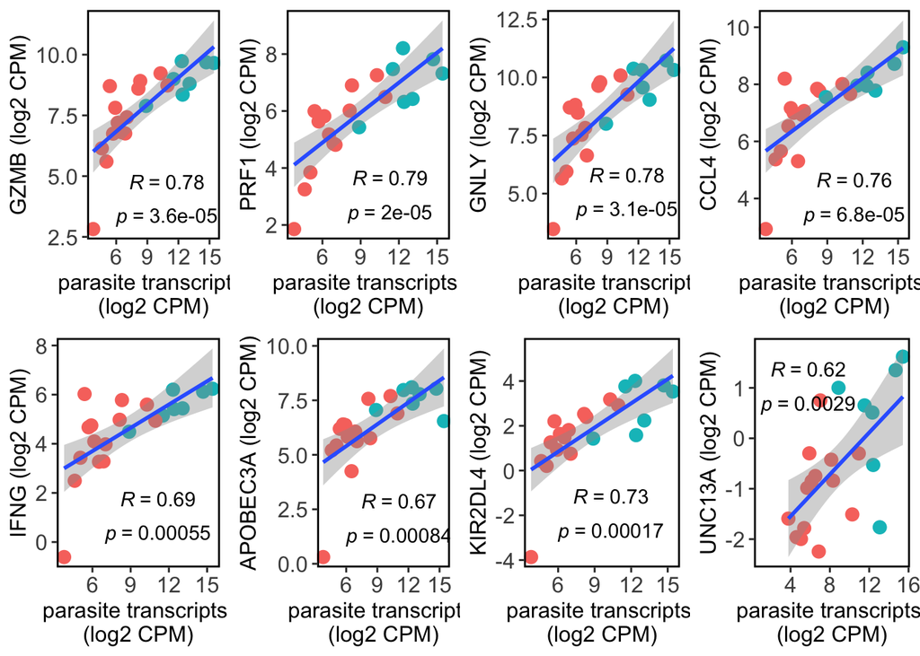

```r
p_PRF1 <- ggplot(targets.onlypatients, aes(x = log2(parasiteTx_CPM_Amorim), y = log2(PRF1))) +
  geom_point(shape = 19, size = 3, aes(colour = as.factor(treatment_outcome))) +
  #geom_smooth(colour = "red", fill = "lightblue", method = 'lm') +
  #ggtitle("Correlation between parasite load (by RNAseq) and IL1B expression") +
  xlab("parasite transcripts \n(log2 CPM)") +
  ylab("PRF1 (log2 CPM)") +
  geom_smooth(method='lm') +
  stat_cor(method = "pearson", label.x = 8, label.y = 3, label.sep = "\n") +
  theme_bw() +
  theme(legend.position = "none",
        axis.text=element_text(size=12),
        axis.title=element_text(size=12),
        plot.title = element_text(face="bold"),
        panel.border = element_rect(colour = "black", fill=NA, size=1),
        panel.grid.major = element_blank(),
        panel.grid.minor = element_blank())

p_GZMB <- ggplot(targets.onlypatients, aes(x = log2(parasiteTx_CPM_Amorim), y = log2(GZMB))) +
  geom_point(shape = 19, size = 3, aes(colour = as.factor(treatment_outcome))) +
  #geom_smooth(colour = "red", fill = "lightblue", method = 'lm') +
  #ggtitle("Correlation between parasite load (by RNAseq) and IL1B expression") +
  xlab("parasite transcripts \n(log2 CPM)") +
  ylab("GZMB (log2 CPM)") +
  geom_smooth(method='lm') +
  stat_cor(method = "pearson", label.x = 6, label.y = 4, label.sep = "\n") +
  theme_bw() +
  theme(legend.position = "none",
        axis.text=element_text(size=12),
        axis.title=element_text(size=12),
        plot.title = element_text(face="bold"),
        panel.border = element_rect(colour = "black", fill=NA, size=1),
        panel.grid.major = element_blank(),
        panel.grid.minor = element_blank())

p_GNLY <- ggplot(targets.onlypatients, aes(x = log2(parasiteTx_CPM_Amorim), y = log2(GNLY))) +
  geom_point(shape = 19, size = 3, aes(colour = as.factor(treatment_outcome))) +
  #geom_smooth(colour = "red", fill = "lightblue", method = 'lm') +
  #ggtitle("Correlation between parasite load (by RNAseq) and IL1B expression") +
  xlab("parasite transcripts \n(log2 CPM)") +
  ylab("GNLY (log2 CPM)") +
  geom_smooth(method='lm') +
  stat_cor(method = "pearson", label.x = 6, label.y = 5, label.sep = "\n") +
  theme_bw() +
  theme(legend.position = "none",
        axis.text=element_text(size=12),
        axis.title=element_text(size=12),
        plot.title = element_text(face="bold"),
        panel.border = element_rect(colour = "black", fill=NA, size=1),
        panel.grid.major = element_blank(),
        panel.grid.minor = element_blank())

p_IFNG <- ggplot(targets.onlypatients, aes(x = log2(parasiteTx_CPM_Amorim), y = log2(IFNG))) +
  geom_point(shape = 19, size = 3, aes(colour = as.factor(treatment_outcome))) +
  #geom_smooth(colour = "red", fill = "lightblue", method = 'lm') +
  #ggtitle("Correlation between parasite load (by RNAseq) and IL1B expression") +
  xlab("parasite transcripts \n(log2 CPM)") +
  ylab("IFNG (log2 CPM)") +
  geom_smooth(method='lm') +
  stat_cor(method = "pearson", label.x = 7, label.y = 1, label.sep = "\n") +
  theme_bw() +
  theme(legend.position = "none",
        axis.text=element_text(size=12),
        axis.title=element_text(size=12),
        plot.title = element_text(face="bold"),
        panel.border = element_rect(colour = "black", fill=NA, size=1),
        panel.grid.major = element_blank(),
        panel.grid.minor = element_blank())

p_UNC13A <- ggplot(targets.onlypatients, aes(x = log2(parasiteTx_CPM_Amorim), y = log2(UNC13A))) +
  geom_point(shape = 19, size = 3, aes(colour = as.factor(treatment_outcome))) +
  #geom_smooth(colour = "red", fill = "lightblue", method = 'lm') +
  #ggtitle("Correlation between parasite load (by RNAseq) and IL1B expression") +
  xlab("parasite transcripts \n(log2 CPM)") +
  ylab("UNC13A (log2 CPM)") +
  geom_smooth(method='lm') +
  stat_cor(method = "pearson", label.x = 1, label.y = 1, label.sep = "\n") +
  theme_bw() +
  theme(legend.position = "none",
        axis.text=element_text(size=12),
        axis.title=element_text(size=12),
        plot.title = element_text(face="bold"),
        panel.border = element_rect(colour = "black", fill=NA, size=1),
        panel.grid.major = element_blank(),
        panel.grid.minor = element_blank())

p_APOBEC3A <- ggplot(targets.onlypatients, aes(x = log2(parasiteTx_CPM_Amorim), y = log2(APOBEC3A))) +
  geom_point(shape = 19, size = 3, aes(colour = as.factor(treatment_outcome))) +
  #geom_smooth(colour = "red", fill = "lightblue", method = 'lm') +
  #ggtitle("Correlation between parasite load (by RNAseq) and IL1B expression") +
  xlab("parasite transcripts \n(log2 CPM)") +
  ylab("APOBEC3A (log2 CPM)") +
  geom_smooth(method='lm') +
  stat_cor(method = "pearson", label.x = 6, label.y = 2, label.sep = "\n") +
  theme_bw() +
  theme(legend.position = "none",
        axis.text=element_text(size=12),
        axis.title=element_text(size=12),
        plot.title = element_text(face="bold"),
        panel.border = element_rect(colour = "black", fill=NA, size=1),
        panel.grid.major = element_blank(),
        panel.grid.minor = element_blank())

p_KIR2DL4 <- ggplot(targets.onlypatients, aes(x = log2(parasiteTx_CPM_Amorim), y = log2(KIR2DL4))) +
  geom_point(shape = 19, size = 3, aes(colour = as.factor(treatment_outcome))) +
  #geom_smooth(colour = "red", fill = "lightblue", method = 'lm') +
  #ggtitle("Correlation between parasite load (by RNAseq) and IL1B expression") +
  xlab("parasite transcripts \n(log2 CPM)") +
  ylab("KIR2DL4 (log2 CPM)") +
  geom_smooth(method='lm') +
  stat_cor(method = "pearson", label.x = 6, label.y = -2, label.sep = "\n") +
  theme_bw() +
  theme(legend.position = "none",
        axis.text=element_text(size=12),
        axis.title=element_text(size=12),
        plot.title = element_text(face="bold"),
        panel.border = element_rect(colour = "black", fill=NA, size=1),
        panel.grid.major = element_blank(),
        panel.grid.minor = element_blank())

p_CCL4 <- ggplot(targets.onlypatients, aes(x = log2(parasiteTx_CPM_Amorim), y = log2(CCL4))) +
  geom_point(shape = 19, size = 3, aes(colour = as.factor(treatment_outcome))) +
  #geom_smooth(colour = "red", fill = "lightblue", method = 'lm') +
  #ggtitle("Correlation between parasite load (by RNAseq) and IL1B expression") +
  xlab("parasite transcripts \n(log2 CPM)") +
  ylab("CCL4 (log2 CPM)") +
  geom_smooth(method='lm') +
  stat_cor(method = "pearson", label.x = 7, label.y = 4, label.sep = "\n") +
  theme_bw() +
  theme(legend.position = "none",
        axis.text=element_text(size=12),
        axis.title=element_text(size=12),
        plot.title = element_text(face="bold"),
        panel.border = element_rect(colour = "black", fill=NA, size=1),
        panel.grid.major = element_blank(),
        panel.grid.minor = element_blank())

plot_grid(p_GZMB, p_PRF1, p_GNLY, p_CCL4, p_IFNG, p_APOBEC3A, p_KIR2DL4, p_UNC13A, nrow=2)
```

# 12 Validation on patient cohort from Christensen et al., PLOS NTD, 2016

## 12.1 Sample info

```r
import <- read_tsv("StudyDesign_Christensen_plosNTD_2016.txt")
import %>% dplyr::filter(disease == "CL" & treatment_outcome != "unclear") %>%
  gt() %>%
  tab_header(title = md("Clinical metadata from patients with cutaneous leishmaniasis (CL) in Christensen et al."),
             subtitle = md("`(n=24)`")) %>%  cols_align(align = "center", columns = TRUE)
```

Clinical metadata from patients with cutaneous leishmaniasis (CL) in Christensen et al.

`(n=24)`

| sample | disease | disease_stage | treatment_outcome | lesion_size | age_(years) | sex | Time_to_cure_(days) | DTH_(mm2) |
| --- | --- | --- | --- | --- | --- | --- | --- | --- |
| SRR3162852 | CL | early | cure | 36 | 44 | F | 60 | na |
| SRR3162853 | CL | early | failure | 40 | 24 | M | more | na |
| SRR3162854 | CL | early | failure | 56 | 31 | F | more | na |
| SRR3162855 | CL | early | failure | 12 | 25 | F | 90 | na |
| SRR3162856 | CL | early | failure | 80 | 33 | M | 90 | na |
| SRR3162857 | CL | early | failure | 120 | 25 | F | 90 | na |
| SRR3162858 | CL | early | failure | 25 | 30 | F | more | na |
| SRR3162859 | CL | early | failure | 4 | 40 | M | more | na |
| SRR3162860 | CL | late | failure | 100 | 25 | M | more | na |
| SRR3162861 | CL | late | cure | 440 | 28 | M | 90 | na |
| SRR3162862 | CL | late | cure | 100 | 19 | M | 60 | na |
| SRR3162863 | CL | late | failure | 560 | 33 | F | more | na |
| SRR3162867 | CL | late | cure | 180 | 18 | M | 60 | na |
| SRR3162864 | CL | late | cure | 252 | 27 | M | 90 | na |
| SRR3162865 | CL | late | cure | 100 | 45 | F | 60 | na |
| SRR3162866 | CL | late | failure | 48 | 21 | M | 90 | na |
| SRR3162868 | CL | late | failure | 550 | 37 | M | 90 | na |
| SRR3162869 | CL | late | cure | 380 | 25 | M | 60 | na |
| SRR3162870 | CL | late | failure | 250 | 30 | M | more | na |
| SRR3162871 | CL | late | cure | 100 | 33 | F | 60 | na |
| SRR3162872 | CL | late | cure | 440 | 25 | M | 90 | na |
| SRR3162873 | CL | late | failure | 192 | 19 | F | 90 | na |
| SRR3162875 | CL | late | failure | 48 | 26 | F | 90 | na |
| SRR3162876 | CL | late | failure | 960 | 19 | M | 90 | na |

```r
targets.lesion <- dplyr::filter(import, treatment_outcome != "unclear")
# only CL lesions where treatment outcome was clear (n=24)
targets.onlypatients <- dplyr::filter(import, disease == "CL" & treatment_outcome != "unclear")

# Making factors that will be used for pairwise comparisons:
# HS vs. CL lesions as a factor:
disease.lesion <- factor(targets.lesion$disease)
# Cure vs. Failure lesions as a factor:
treatment.lesion <- factor(targets.onlypatients$treatment_outcome)
```

## 12.2 mapping raw reads to human reference

```bash
# First the healthy controls
kallisto quant -i Homo_sapiens.GRCh38.cdna.all.Index -o host_SRR3162842 -b 60 -t 24 SRR3162842_1.fastq.gz SRR3162842_2.fastq.gz &> host_SRR3162842.log
kallisto quant -i Homo_sapiens.GRCh38.cdna.all.Index -o host_SRR3162843 -b 60 -t 24 SRR3162843_1.fastq.gz SRR3162843_2.fastq.gz &> host_SRR3162843.log
kallisto quant -i Homo_sapiens.GRCh38.cdna.all.Index -o host_SRR3162844 -b 60 -t 24 SRR3162844_1.fastq.gz SRR3162844_2.fastq.gz &> host_SRR3162844.log
kallisto quant -i Homo_sapiens.GRCh38.cdna.all.Index -o host_SRR3162845 -b 60 -t 24 SRR3162845_1.fastq.gz SRR3162845_2.fastq.gz &> host_SRR3162845.log
kallisto quant -i Homo_sapiens.GRCh38.cdna.all.Index -o host_SRR3162846 -b 60 -t 24 SRR3162846_1.fastq.gz SRR3162846_2.fastq.gz &> host_SRR3162846.log
kallisto quant -i Homo_sapiens.GRCh38.cdna.all.Index -o host_SRR3162847 -b 60 -t 24 SRR3162847_1.fastq.gz SRR3162847_2.fastq.gz &> host_SRR3162847.log
kallisto quant -i Homo_sapiens.GRCh38.cdna.all.Index -o host_SRR3162848 -b 60 -t 24 SRR3162848_1.fastq.gz SRR3162848_2.fastq.gz &> host_SRR3162848.log
kallisto quant -i Homo_sapiens.GRCh38.cdna.all.Index -o host_SRR3162849 -b 60 -t 24 SRR3162849_1.fastq.gz SRR3162849_2.fastq.gz &> host_SRR3162849.log
kallisto quant -i Homo_sapiens.GRCh38.cdna.all.Index -o host_SRR3162850 -b 60 -t 24 SRR3162850_1.fastq.gz SRR3162850_2.fastq.gz &> host_SRR3162850.log
kallisto quant -i Homo_sapiens.GRCh38.cdna.all.Index -o host_SRR3162851 -b 60 -t 24 SRR3162851_1.fastq.gz SRR3162851_2.fastq.gz &> host_SRR3162851.log

# Then the cutaneous leishmaniasis patients
kallisto quant -i Homo_sapiens.GRCh38.cdna.all.Index -o host_SRR3162852 -b 60 -t 24 SRR3162852_1.fastq.gz SRR3162852_2.fastq.gz &> host_SRR3162852.log
kallisto quant -i Homo_sapiens.GRCh38.cdna.all.Index -o host_SRR3162853 -b 60 -t 24 SRR3162853_1.fastq.gz SRR3162853_2.fastq.gz &> host_SRR3162853.log
kallisto quant -i Homo_sapiens.GRCh38.cdna.all.Index -o host_SRR3162854 -b 60 -t 24 SRR3162854_1.fastq.gz SRR3162854_2.fastq.gz &> host_SRR3162854.log
kallisto quant -i Homo_sapiens.GRCh38.cdna.all.Index -o host_SRR3162855 -b 60 -t 24 SRR3162855_1.fastq.gz SRR3162855_2.fastq.gz &> host_SRR3162855.log
kallisto quant -i Homo_sapiens.GRCh38.cdna.all.Index -o host_SRR3162856 -b 60 -t 24 SRR3162856_1.fastq.gz SRR3162856_2.fastq.gz &> host_SRR3162856.log
kallisto quant -i Homo_sapiens.GRCh38.cdna.all.Index -o host_SRR3162857 -b 60 -t 24 SRR3162857_1.fastq.gz SRR3162857_2.fastq.gz &> host_SRR3162857.log
kallisto quant -i Homo_sapiens.GRCh38.cdna.all.Index -o host_SRR3162858 -b 60 -t 24 SRR3162858_1.fastq.gz SRR3162858_2.fastq.gz &> host_SRR3162858.log
kallisto quant -i Homo_sapiens.GRCh38.cdna.all.Index -o host_SRR3162859 -b 60 -t 24 SRR3162859_1.fastq.gz SRR3162859_2.fastq.gz &> host_SRR3162859.log
kallisto quant -i Homo_sapiens.GRCh38.cdna.all.Index -o host_SRR3162860 -b 60 -t 24 SRR3162860_1.fastq.gz SRR3162860_2.fastq.gz &> host_SRR3162860.log
kallisto quant -i Homo_sapiens.GRCh38.cdna.all.Index -o host_SRR3162861 -b 60 -t 24 SRR3162861_1.fastq.gz SRR3162861_2.fastq.gz &> host_SRR3162861.log
kallisto quant -i Homo_sapiens.GRCh38.cdna.all.Index -o host_SRR3162862 -b 60 -t 24 SRR3162862_1.fastq.gz SRR3162862_2.fastq.gz &> host_SRR3162862.log
kallisto quant -i Homo_sapiens.GRCh38.cdna.all.Index -o host_SRR3162863 -b 60 -t 24 SRR3162863_1.fastq.gz SRR3162863_2.fastq.gz &> host_SRR3162863.log
kallisto quant -i Homo_sapiens.GRCh38.cdna.all.Index -o host_SRR3162864 -b 60 -t 24 SRR3162864_1.fastq.gz SRR3162864_2.fastq.gz &> host_SRR3162864.log
kallisto quant -i Homo_sapiens.GRCh38.cdna.all.Index -o host_SRR3162865 -b 60 -t 24 SRR3162865_1.fastq.gz SRR3162865_2.fastq.gz &> host_SRR3162865.log
kallisto quant -i Homo_sapiens.GRCh38.cdna.all.Index -o host_SRR3162866 -b 60 -t 24 SRR3162866_1.fastq.gz SRR3162866_2.fastq.gz &> host_SRR3162866.log
kallisto quant -i Homo_sapiens.GRCh38.cdna.all.Index -o host_SRR3162867 -b 60 -t 24 SRR3162867_1.fastq.gz SRR3162867_2.fastq.gz &> host_SRR3162867.log
kallisto quant -i Homo_sapiens.GRCh38.cdna.all.Index -o host_SRR3162868 -b 60 -t 24 SRR3162868_1.fastq.gz SRR3162868_2.fastq.gz &> host_SRR3162868.log
kallisto quant -i Homo_sapiens.GRCh38.cdna.all.Index -o host_SRR3162869 -b 60 -t 24 SRR3162869_1.fastq.gz SRR3162869_2.fastq.gz &> host_SRR3162869.log
kallisto quant -i Homo_sapiens.GRCh38.cdna.all.Index -o host_SRR3162870 -b 60 -t 24 SRR3162870_1.fastq.gz SRR3162870_2.fastq.gz &> host_SRR3162870.log
kallisto quant -i Homo_sapiens.GRCh38.cdna.all.Index -o host_SRR3162871 -b 60 -t 24 SRR3162871_1.fastq.gz SRR3162871_2.fastq.gz &> host_SRR3162871.log
kallisto quant -i Homo_sapiens.GRCh38.cdna.all.Index -o host_SRR3162872 -b 60 -t 24 SRR3162872_1.fastq.gz SRR3162872_2.fastq.gz &> host_SRR3162872.log
kallisto quant -i Homo_sapiens.GRCh38.cdna.all.Index -o host_SRR3162873 -b 60 -t 24 SRR3162873_1.fastq.gz SRR3162873_2.fastq.gz &> host_SRR3162873.log
kallisto quant -i Homo_sapiens.GRCh38.cdna.all.Index -o host_SRR3162874 -b 60 -t 24 SRR3162874_1.fastq.gz SRR3162874_2.fastq.gz &> host_SRR3162874.log
kallisto quant -i Homo_sapiens.GRCh38.cdna.all.Index -o host_SRR3162875 -b 60 -t 24 SRR3162875_1.fastq.gz SRR3162875_2.fastq.gz &> host_SRR3162875.log
kallisto quant -i Homo_sapiens.GRCh38.cdna.all.Index -o host_SRR3162876 -b 60 -t 24 SRR3162876_1.fastq.gz SRR3162876_2.fastq.gz &> host_SRR3162876.log
```

## 12.3 QC of raw data and read mapping

As was done before, quality control of raw reads was carried out using [fastqc](https://www.bioinformatics.babraham.ac.uk/projects/fastqc/). The quality of raw reads, as well as the results of Kallisto mapping for the Christensen et al. dataset were summarized using [multiqc](https://multiqc.info/). The resulting multiqc report can be found in the [github project repo](https://github.com/dpbisme/Amorim_CutaneousLeish_biomarkers) in the `QA` directory. *Note*: due to size limitations imposed by Github, neither the raw fastq files, nor the reference fasta file used for read mapping could be stored in the GitHub repo.

## 12.4 importing human data

```r
# Importing .h5 Kallisto outputs and annotate transcripts to gene symbols:
paths.all <- file.path("../Christensen_plosNTD_2016/human", paste0("host_", targets.lesion$sample), "abundance.h5")
paths.patients <- file.path("../Christensen_plosNTD_2016/human", paste0("host_", targets.onlypatients$sample), "abundance.h5")

Txi.lesion.Christensen <- tximport(paths.all,
                              type = "kallisto",
                              tx2gene = Tx,
                              txOut = FALSE,
                              ignoreTxVersion = TRUE,
                              countsFromAbundance = "lengthScaledTPM")

Txi.lesion.Christensen.onlypatients <- tximport(paths.patients,
                                           type = "kallisto",
                                           tx2gene = Tx,
                                           txOut = FALSE,
                                           ignoreTxVersion = TRUE,
                                           countsFromAbundance = "lengthScaledTPM")
```

## 12.5 filtering out host reads

```bash
# first the healthy subjects (HS).
kneaddata -i SRR3162842.fastq.gz -db /data/reference_db/Homo_sapiens/Ensembl/GRCh37/Sequence/Bowtie2Index -o SRR3162842_filtered -t 24
kneaddata -i SRR3162843.fastq.gz -db /data/reference_db/Homo_sapiens/Ensembl/GRCh37/Sequence/Bowtie2Index -o SRR3162843_filtered -t 24
kneaddata -i SRR3162844.fastq.gz -db /data/reference_db/Homo_sapiens/Ensembl/GRCh37/Sequence/Bowtie2Index -o SRR3162844_filtered -t 24
kneaddata -i SRR3162845.fastq.gz -db /data/reference_db/Homo_sapiens/Ensembl/GRCh37/Sequence/Bowtie2Index -o SRR3162845_filtered -t 24
kneaddata -i SRR3162846.fastq.gz -db /data/reference_db/Homo_sapiens/Ensembl/GRCh37/Sequence/Bowtie2Index -o SRR3162846_filtered -t 24
kneaddata -i SRR3162847.fastq.gz -db /data/reference_db/Homo_sapiens/Ensembl/GRCh37/Sequence/Bowtie2Index -o SRR3162847_filtered -t 24
kneaddata -i SRR3162848.fastq.gz -db /data/reference_db/Homo_sapiens/Ensembl/GRCh37/Sequence/Bowtie2Index -o SRR3162848_filtered -t 24
kneaddata -i SRR3162849.fastq.gz -db /data/reference_db/Homo_sapiens/Ensembl/GRCh37/Sequence/Bowtie2Index -o SRR3162849_filtered -t 24
kneaddata -i SRR3162850.fastq.gz -db /data/reference_db/Homo_sapiens/Ensembl/GRCh37/Sequence/Bowtie2Index -o SRR3162850_filtered -t 24
kneaddata -i SRR3162851.fastq.gz -db /data/reference_db/Homo_sapiens/Ensembl/GRCh37/Sequence/Bowtie2Index -o SRR3162851_filtered -t 24

# then the cutaneous leishmaniasis (CL) patients
kneaddata -i SRR3162852.fastq.gz -db /data/reference_db/Homo_sapiens/Ensembl/GRCh37/Sequence/Bowtie2Index -o SRR3162852_filtered -t 24
kneaddata -i SRR3162853.fastq.gz -db /data/reference_db/Homo_sapiens/Ensembl/GRCh37/Sequence/Bowtie2Index -o SRR3162853_filtered -t 24
kneaddata -i SRR3162854.fastq.gz -db /data/reference_db/Homo_sapiens/Ensembl/GRCh37/Sequence/Bowtie2Index -o SRR3162854_filtered -t 24
kneaddata -i SRR3162855.fastq.gz -db /data/reference_db/Homo_sapiens/Ensembl/GRCh37/Sequence/Bowtie2Index -o SRR3162855_filtered -t 24
kneaddata -i SRR3162856.fastq.gz -db /data/reference_db/Homo_sapiens/Ensembl/GRCh37/Sequence/Bowtie2Index -o SRR3162856_filtered -t 24
kneaddata -i SRR3162857.fastq.gz -db /data/reference_db/Homo_sapiens/Ensembl/GRCh37/Sequence/Bowtie2Index -o SRR3162857_filtered -t 24
kneaddata -i SRR3162858.fastq.gz -db /data/reference_db/Homo_sapiens/Ensembl/GRCh37/Sequence/Bowtie2Index -o SRR3162858_filtered -t 24
kneaddata -i SRR3162859.fastq.gz -db /data/reference_db/Homo_sapiens/Ensembl/GRCh37/Sequence/Bowtie2Index -o SRR3162859_filtered -t 24
kneaddata -i SRR3162860.fastq.gz -db /data/reference_db/Homo_sapiens/Ensembl/GRCh37/Sequence/Bowtie2Index -o SRR3162860_filtered -t 24
kneaddata -i SRR3162861.fastq.gz -db /data/reference_db/Homo_sapiens/Ensembl/GRCh37/Sequence/Bowtie2Index -o SRR3162861_filtered -t 24
kneaddata -i SRR3162862.fastq.gz -db /data/reference_db/Homo_sapiens/Ensembl/GRCh37/Sequence/Bowtie2Index -o SRR3162862_filtered -t 24
kneaddata -i SRR3162863.fastq.gz -db /data/reference_db/Homo_sapiens/Ensembl/GRCh37/Sequence/Bowtie2Index -o SRR3162863_filtered -t 24
kneaddata -i SRR3162867.fastq.gz -db /data/reference_db/Homo_sapiens/Ensembl/GRCh37/Sequence/Bowtie2Index -o SRR3162867_filtered -t 24
kneaddata -i SRR3162864.fastq.gz -db /data/reference_db/Homo_sapiens/Ensembl/GRCh37/Sequence/Bowtie2Index -o SRR3162864_filtered -t 24
kneaddata -i SRR3162865.fastq.gz -db /data/reference_db/Homo_sapiens/Ensembl/GRCh37/Sequence/Bowtie2Index -o SRR3162865_filtered -t 24
kneaddata -i SRR3162866.fastq.gz -db /data/reference_db/Homo_sapiens/Ensembl/GRCh37/Sequence/Bowtie2Index -o SRR3162866_filtered -t 24
kneaddata -i SRR3162868.fastq.gz -db /data/reference_db/Homo_sapiens/Ensembl/GRCh37/Sequence/Bowtie2Index -o SRR3162868_filtered -t 24
kneaddata -i SRR3162869.fastq.gz -db /data/reference_db/Homo_sapiens/Ensembl/GRCh37/Sequence/Bowtie2Index -o SRR3162869_filtered -t 24
kneaddata -i SRR3162870.fastq.gz -db /data/reference_db/Homo_sapiens/Ensembl/GRCh37/Sequence/Bowtie2Index -o SRR3162870_filtered -t 24
kneaddata -i SRR3162871.fastq.gz -db /data/reference_db/Homo_sapiens/Ensembl/GRCh37/Sequence/Bowtie2Index -o SRR3162871_filtered -t 24
kneaddata -i SRR3162872.fastq.gz -db /data/reference_db/Homo_sapiens/Ensembl/GRCh37/Sequence/Bowtie2Index -o SRR3162872_filtered -t 24
kneaddata -i SRR3162873.fastq.gz -db /data/reference_db/Homo_sapiens/Ensembl/GRCh37/Sequence/Bowtie2Index -o SRR3162873_filtered -t 24
kneaddata -i SRR3162874.fastq.gz -db /data/reference_db/Homo_sapiens/Ensembl/GRCh37/Sequence/Bowtie2Index -o SRR3162874_filtered -t 24
kneaddata -i SRR3162875.fastq.gz -db /data/reference_db/Homo_sapiens/Ensembl/GRCh37/Sequence/Bowtie2Index -o SRR3162875_filtered -t 24
kneaddata -i SRR3162876.fastq.gz -db /data/reference_db/Homo_sapiens/Ensembl/GRCh37/Sequence/Bowtie2Index -o SRR3162876_filtered -t 24
```

## 12.6 mapping filtered reads to *L. braziliensis*

```bash
# first the healthy subjects (HS).
kallisto quant -i Leishmania_braziliensis_mhom_br_75_m2904.ASM284v2.cdna.all.index -o parasite_SRR3162842 -b 60 -t 24 SRR3162842_1_kneaddata.fastq SRR3162842_2_kneaddata.fastq &> parasite_SRR3162842.log
kallisto quant -i Leishmania_braziliensis_mhom_br_75_m2904.ASM284v2.cdna.all.index -o parasite_SRR3162843 -b 60 -t 24 SRR3162843_1_kneaddata.fastq SRR3162843_2_kneaddata.fastq &> parasite_SRR3162843.log
kallisto quant -i Leishmania_braziliensis_mhom_br_75_m2904.ASM284v2.cdna.all.index -o parasite_SRR3162844 -b 60 -t 24 SRR3162844_1_kneaddata.fastq SRR3162844_2_kneaddata.fastq &> parasite_SRR3162844.log
kallisto quant -i Leishmania_braziliensis_mhom_br_75_m2904.ASM284v2.cdna.all.index -o parasite_SRR3162845 -b 60 -t 24 SRR3162845_1_kneaddata.fastq SRR3162845_2_kneaddata.fastq &> parasite_SRR3162845.log
kallisto quant -i Leishmania_braziliensis_mhom_br_75_m2904.ASM284v2.cdna.all.index -o parasite_SRR3162846 -b 60 -t 24 SRR3162846_1_kneaddata.fastq SRR3162846_2_kneaddata.fastq &> parasite_SRR3162846.log
kallisto quant -i Leishmania_braziliensis_mhom_br_75_m2904.ASM284v2.cdna.all.index -o parasite_SRR3162847 -b 60 -t 24 SRR3162847_1_kneaddata.fastq SRR3162847_2_kneaddata.fastq &> parasite_SRR3162847.log
kallisto quant -i Leishmania_braziliensis_mhom_br_75_m2904.ASM284v2.cdna.all.index -o parasite_SRR3162848 -b 60 -t 24 SRR3162848_1_kneaddata.fastq SRR3162848_2_kneaddata.fastq &> parasite_SRR3162848.log
kallisto quant -i Leishmania_braziliensis_mhom_br_75_m2904.ASM284v2.cdna.all.index -o parasite_SRR3162849 -b 60 -t 24 SRR3162849_1_kneaddata.fastq SRR3162849_2_kneaddata.fastq &> parasite_SRR3162849.log
kallisto quant -i Leishmania_braziliensis_mhom_br_75_m2904.ASM284v2.cdna.all.index -o parasite_SRR3162850 -b 60 -t 24 SRR3162850_1_kneaddata.fastq SRR3162850_2_kneaddata.fastq &> parasite_SRR3162850.log
kallisto quant -i Leishmania_braziliensis_mhom_br_75_m2904.ASM284v2.cdna.all.index -o parasite_SRR3162851 -b 60 -t 24 SRR3162851_1_kneaddata.fastq SRR3162851_2_kneaddata.fastq &> parasite_SRR3162851.log

# then the cutaneous leishmaniasis (CL) patients
kallisto quant -i Leishmania_braziliensis_mhom_br_75_m2904.ASM284v2.cdna.all.index -o parasite_SRR3162852 -b 60 -t 24 SRR3162852_1_kneaddata.fastq SRR3162852_2_kneaddata.fastq &> parasite_SRR3162852.log
kallisto quant -i Leishmania_braziliensis_mhom_br_75_m2904.ASM284v2.cdna.all.index -o parasite_SRR3162853 -b 60 -t 24 SRR3162853_1_kneaddata.fastq SRR3162853_2_kneaddata.fastq &> parasite_SRR3162853.log
kallisto quant -i Leishmania_braziliensis_mhom_br_75_m2904.ASM284v2.cdna.all.index -o parasite_SRR3162854 -b 60 -t 24 SRR3162854_1_kneaddata.fastq SRR3162854_2_kneaddata.fastq &> parasite_SRR3162854.log
kallisto quant -i Leishmania_braziliensis_mhom_br_75_m2904.ASM284v2.cdna.all.index -o parasite_SRR3162855 -b 60 -t 24 SRR3162855_1_kneaddata.fastq SRR3162855_2_kneaddata.fastq &> parasite_SRR3162855.log
kallisto quant -i Leishmania_braziliensis_mhom_br_75_m2904.ASM284v2.cdna.all.index -o parasite_SRR3162856 -b 60 -t 24 SRR3162856_1_kneaddata.fastq SRR3162856_2_kneaddata.fastq &> parasite_SRR3162856.log
kallisto quant -i Leishmania_braziliensis_mhom_br_75_m2904.ASM284v2.cdna.all.index -o parasite_SRR3162857 -b 60 -t 24 SRR3162857_1_kneaddata.fastq SRR3162857_2_kneaddata.fastq &> parasite_SRR3162857.log
kallisto quant -i Leishmania_braziliensis_mhom_br_75_m2904.ASM284v2.cdna.all.index -o parasite_SRR3162858 -b 60 -t 24 SRR3162858_1_kneaddata.fastq SRR3162858_2_kneaddata.fastq &> parasite_SRR3162858.log
kallisto quant -i Leishmania_braziliensis_mhom_br_75_m2904.ASM284v2.cdna.all.index -o parasite_SRR3162859 -b 60 -t 24 SRR3162859_1_kneaddata.fastq SRR3162859_2_kneaddata.fastq &> parasite_SRR3162859.log
kallisto quant -i Leishmania_braziliensis_mhom_br_75_m2904.ASM284v2.cdna.all.index -o parasite_SRR3162860 -b 60 -t 24 SRR3162860_1_kneaddata.fastq SRR3162860_2_kneaddata.fastq &> parasite_SRR3162860.log
kallisto quant -i Leishmania_braziliensis_mhom_br_75_m2904.ASM284v2.cdna.all.index -o parasite_SRR3162861 -b 60 -t 24 SRR3162861_1_kneaddata.fastq SRR3162861_2_kneaddata.fastq &> parasite_SRR3162861.log
kallisto quant -i Leishmania_braziliensis_mhom_br_75_m2904.ASM284v2.cdna.all.index -o parasite_SRR3162862 -b 60 -t 24 SRR3162862_1_kneaddata.fastq SRR3162862_2_kneaddata.fastq &> parasite_SRR3162862.log
kallisto quant -i Leishmania_braziliensis_mhom_br_75_m2904.ASM284v2.cdna.all.index -o parasite_SRR3162863 -b 60 -t 24 SRR3162863_1_kneaddata.fastq SRR3162863_2_kneaddata.fastq &> parasite_SRR3162863.log
kallisto quant -i Leishmania_braziliensis_mhom_br_75_m2904.ASM284v2.cdna.all.index -o parasite_SRR3162864 -b 60 -t 24 SRR3162864_1_kneaddata.fastq SRR3162864_2_kneaddata.fastq &> parasite_SRR3162864.log
kallisto quant -i Leishmania_braziliensis_mhom_br_75_m2904.ASM284v2.cdna.all.index -o parasite_SRR3162865 -b 60 -t 24 SRR3162865_1_kneaddata.fastq SRR3162865_2_kneaddata.fastq &> parasite_SRR3162865.log
kallisto quant -i Leishmania_braziliensis_mhom_br_75_m2904.ASM284v2.cdna.all.index -o parasite_SRR3162866 -b 60 -t 24 SRR3162866_1_kneaddata.fastq SRR3162866_2_kneaddata.fastq &> parasite_SRR3162866.log
kallisto quant -i Leishmania_braziliensis_mhom_br_75_m2904.ASM284v2.cdna.all.index -o parasite_SRR3162867 -b 60 -t 24 SRR3162867_1_kneaddata.fastq SRR3162867_2_kneaddata.fastq &> parasite_SRR3162867.log
kallisto quant -i Leishmania_braziliensis_mhom_br_75_m2904.ASM284v2.cdna.all.index -o parasite_SRR3162868 -b 60 -t 24 SRR3162868_1_kneaddata.fastq SRR3162868_2_kneaddata.fastq &> parasite_SRR3162868.log
kallisto quant -i Leishmania_braziliensis_mhom_br_75_m2904.ASM284v2.cdna.all.index -o parasite_SRR3162869 -b 60 -t 24 SRR3162869_1_kneaddata.fastq SRR3162869_2_kneaddata.fastq &> parasite_SRR3162869.log
kallisto quant -i Leishmania_braziliensis_mhom_br_75_m2904.ASM284v2.cdna.all.index -o parasite_SRR3162870 -b 60 -t 24 SRR3162870_1_kneaddata.fastq SRR3162870_2_kneaddata.fastq &> parasite_SRR3162870.log
kallisto quant -i Leishmania_braziliensis_mhom_br_75_m2904.ASM284v2.cdna.all.index -o parasite_SRR3162871 -b 60 -t 24 SRR3162871_1_kneaddata.fastq SRR3162871_2_kneaddata.fastq &> parasite_SRR3162871.log
kallisto quant -i Leishmania_braziliensis_mhom_br_75_m2904.ASM284v2.cdna.all.index -o parasite_SRR3162872 -b 60 -t 24 SRR3162872_1_kneaddata.fastq SRR3162872_2_kneaddata.fastq &> parasite_SRR3162872.log
kallisto quant -i Leishmania_braziliensis_mhom_br_75_m2904.ASM284v2.cdna.all.index -o parasite_SRR3162873 -b 60 -t 24 SRR3162873_1_kneaddata.fastq SRR3162873_2_kneaddata.fastq &> parasite_SRR3162873.log
kallisto quant -i Leishmania_braziliensis_mhom_br_75_m2904.ASM284v2.cdna.all.index -o parasite_SRR3162874 -b 60 -t 24 SRR3162874_1_kneaddata.fastq SRR3162874_2_kneaddata.fastq &> parasite_SRR3162874.log
kallisto quant -i Leishmania_braziliensis_mhom_br_75_m2904.ASM284v2.cdna.all.index -o parasite_SRR3162875 -b 60 -t 24 SRR3162875_1_kneaddata.fastq SRR3162875_2_kneaddata.fastq &> parasite_SRR3162875.log
kallisto quant -i Leishmania_braziliensis_mhom_br_75_m2904.ASM284v2.cdna.all.index -o parasite_SRR3162876 -b 60 -t 24 SRR3162876_1_kneaddata.fastq SRR3162876_2_kneaddata.fastq &> parasite_SRR3162876.log
```

## 12.7 Parasite reads by treatment outcome -

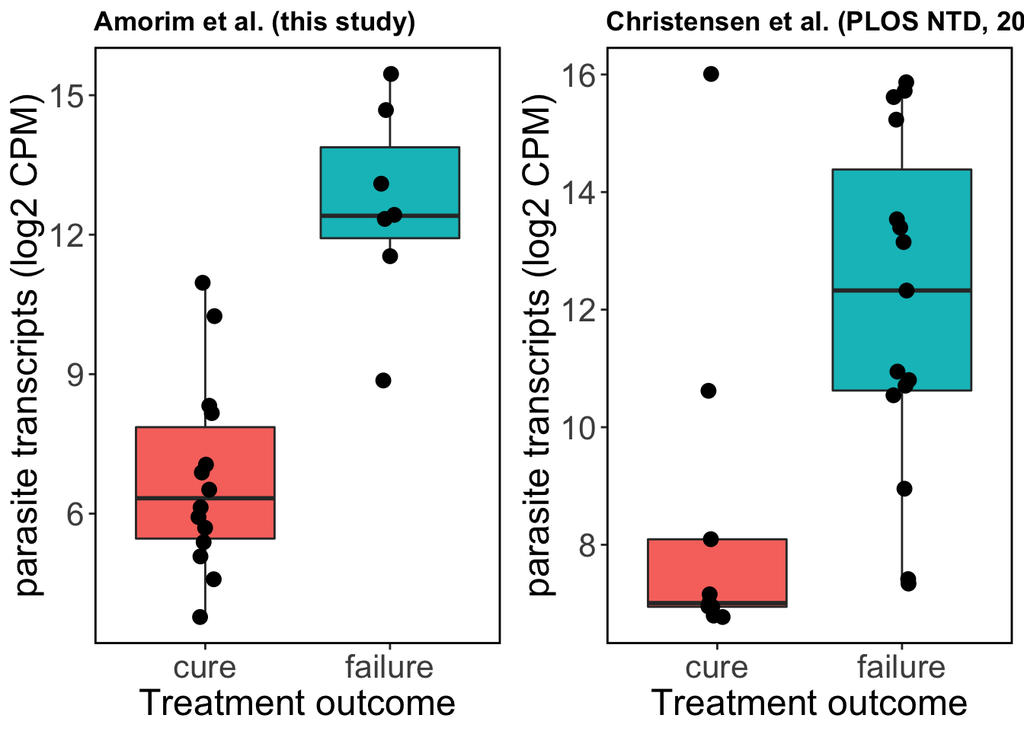

```r
paths.patients.Christensen.parasite <- file.path("../Christensen_plosNTD_2016/Lbraz", paste0("parasite_", targets.onlypatients$sample), "abundance.h5")

Txi.lesion.Christensen.parasite <- tximport(paths.patients.Christensen.parasite,
                                            type = "kallisto",
                                            txOut = TRUE,
                                            ignoreTxVersion = TRUE,
                                            countsFromAbundance = "lengthScaledTPM")


#modifying the patient-level data to include parasite counts, as well as expresion of selected ViTALs
ViTALs_selected_Christensen <- Txi.lesion.Christensen.onlypatients$abundance %>%
  as_tibble(rownames = "geneSymbol") %>%
  dplyr::filter(geneSymbol == "PRF1" | geneSymbol =="GNLY" | geneSymbol == "GZMB" | geneSymbol =="IFNG"
                | geneSymbol == "UNC13A" | geneSymbol =="KIR2DL4" | geneSymbol == "CCL4" | geneSymbol =="APOBEC3A")


geneSymbols_ViTALS_selected <- ViTALs_selected_Christensen$geneSymbol
ViTALs_selected_Christensen <- as.data.frame(t(ViTALs_selected_Christensen[,-1]))
colnames(ViTALs_selected_Christensen) <- geneSymbols_ViTALS_selected

#number of reads remaining after removing host reads above
librarySize.CL <- c(5112799, 5138357, 9712437, 10867257, 7564381,
                    10339099, 3576442, 3774463, 5588509, 5341356,
                    5721003, 4766394, 4538135, 5060671, 5166608,
                    5067688, 4414686, 4334193, 8849480, 3886005,
                    4313191, 4033585, 3485099, 5532895)

librarySize.CL <- librarySize.CL/1000000
parasiteTx_CPM_Christensen <- colSums(Txi.lesion.Christensen.parasite$counts)/librarySize.CL

targets.onlypatients <- targets.onlypatients %>%
  dplyr::mutate(parasiteTx_CPM_Christensen = parasiteTx_CPM_Christensen) %>%
  dplyr::mutate(PRF1 = ViTALs_selected_Christensen$PRF1) %>%
  dplyr::mutate(GZMB = ViTALs_selected_Christensen$GZMB) %>%
  dplyr::mutate(CCL4 = ViTALs_selected_Christensen$CCL4) %>%
  dplyr::mutate(GNLY = ViTALs_selected_Christensen$GNLY) %>%
  dplyr::mutate(UNC13A = ViTALs_selected_Christensen$UNC13A) %>%
  dplyr::mutate(APOBEC3A = ViTALs_selected_Christensen$APOBEC3A) %>%
  dplyr::mutate(KIR2DL4 = ViTALs_selected_Christensen$KIR2DL4) %>%
  dplyr::mutate(IFNG = ViTALs_selected_Christensen$IFNG)

p2 <- ggplot(targets.onlypatients, aes(x=treatment_outcome, y=log2(parasiteTx_CPM_Christensen), fill=treatment_outcome)) +
  geom_boxplot(outlier.shape = NA) +
  labs(y="parasite transcripts (log2 CPM)", x = "Treatment outcome",
       title = "Christensen et al. (PLOS NTD, 2016)") +
  geom_jitter(width = .05, size=3) +
  theme_bw() +
  theme(legend.position = "none",
        axis.text=element_text(size=16),
        axis.title=element_text(size=18),
        plot.title = element_text(face="bold"),
        panel.border = element_rect(colour = "black", fill=NA, size=1),
        panel.grid.major = element_blank(),
        panel.grid.minor = element_blank())

plot_grid(p1, p2)
```

## 12.8 validation of 8 ViTALs conserved between Amorim et al. and Christensen et al.

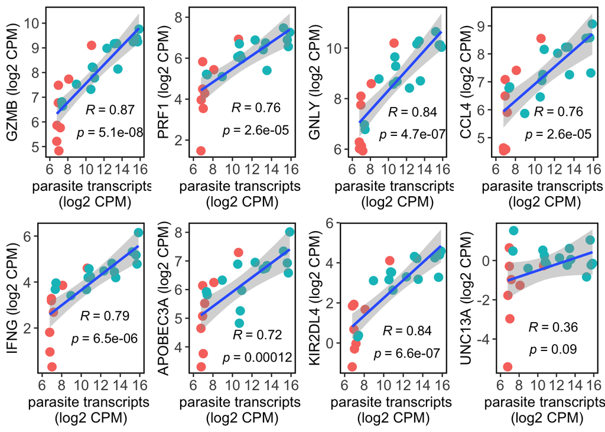

```r
p_PRF1 <- ggplot(targets.onlypatients, aes(x = log2(parasiteTx_CPM_Christensen), y = log2(PRF1))) +
  geom_point(shape = 19, size = 3, aes(colour = as.factor(treatment_outcome))) +
  #geom_smooth(colour = "red", fill = "lightblue", method = 'lm') +
  #ggtitle("Correlation between parasite load (by RNAseq) and IL1B expression") +
  xlab("parasite transcripts \n(log2 CPM)") +
  ylab("PRF1 (log2 CPM)") +
  geom_smooth(method='lm') +
  stat_cor(method = "pearson", label.x = 9, label.y = 3, label.sep = "\n") +
  theme_bw() +
  xlim(6, 16) +
  theme(legend.position = "none",
        axis.text=element_text(size=12),
        axis.title=element_text(size=12),
        plot.title = element_text(face="bold"),
        panel.border = element_rect(colour = "black", fill=NA, size=1),
        panel.grid.major = element_blank(),
        panel.grid.minor = element_blank())

p_GZMB <- ggplot(targets.onlypatients, aes(x = log2(parasiteTx_CPM_Christensen), y = log2(GZMB))) +
  geom_point(shape = 19, size = 3, aes(colour = as.factor(treatment_outcome))) +
  #geom_smooth(colour = "red", fill = "lightblue", method = 'lm') +
  #ggtitle("Correlation between parasite load (by RNAseq) and IL1B expression") +
  xlab("parasite transcripts \n(log2 CPM)") +
  ylab("GZMB (log2 CPM)") +
  geom_smooth(method='lm') +
  stat_cor(method = "pearson", label.x = 9, label.y = 6, label.sep = "\n") +
  theme_bw() +
  xlim(6, 16) +
  theme(legend.position = "none",
        axis.text=element_text(size=12),
        axis.title=element_text(size=12),
        plot.title = element_text(face="bold"),
        panel.border = element_rect(colour = "black", fill=NA, size=1),
        panel.grid.major = element_blank(),
        panel.grid.minor = element_blank())

p_GNLY <- ggplot(targets.onlypatients, aes(x = log2(parasiteTx_CPM_Christensen), y = log2(GNLY))) +
  geom_point(shape = 19, size = 3, aes(colour = as.factor(treatment_outcome))) +
  #geom_smooth(colour = "red", fill = "lightblue", method = 'lm') +
  #ggtitle("Correlation between parasite load (by RNAseq) and IL1B expression") +
  xlab("parasite transcripts \n(log2 CPM)") +
  ylab("GNLY (log2 CPM)") +
  geom_smooth(method='lm') +
  stat_cor(method = "pearson", label.x = 9, label.y = 7, label.sep = "\n") +
  theme_bw() +
  xlim(6, 16) +
  theme(legend.position = "none",
        axis.text=element_text(size=12),
        axis.title=element_text(size=12),
        plot.title = element_text(face="bold"),
        panel.border = element_rect(colour = "black", fill=NA, size=1),
        panel.grid.major = element_blank(),
        panel.grid.minor = element_blank())

p_IFNG <- ggplot(targets.onlypatients, aes(x = log2(parasiteTx_CPM_Christensen), y = log2(IFNG))) +
  geom_point(shape = 19, size = 3, aes(colour = as.factor(treatment_outcome))) +
  #geom_smooth(colour = "red", fill = "lightblue", method = 'lm') +
  #ggtitle("Correlation between parasite load (by RNAseq) and IL1B expression") +
  xlab("parasite transcripts \n(log2 CPM)") +
  ylab("IFNG (log2 CPM)") +
  geom_smooth(method='lm') +
  stat_cor(method = "pearson", label.x = 9, label.y = 2, label.sep = "\n") +
  theme_bw() +
  xlim(6, 16) +
  theme(legend.position = "none",
        axis.text=element_text(size=12),
        axis.title=element_text(size=12),
        plot.title = element_text(face="bold"),
        panel.border = element_rect(colour = "black", fill=NA, size=1),
        panel.grid.major = element_blank(),
        panel.grid.minor = element_blank())

p_UNC13A <- ggplot(targets.onlypatients, aes(x = log2(parasiteTx_CPM_Christensen), y = log2(UNC13A))) +
  geom_point(shape = 19, size = 3, aes(colour = as.factor(treatment_outcome))) +
  #geom_smooth(colour = "red", fill = "lightblue", method = 'lm') +
  #ggtitle("Correlation between parasite load (by RNAseq) and IL1B expression") +
  xlab("parasite transcripts \n(log2 CPM)") +
  ylab("UNC13A (log2 CPM)") +
  geom_smooth(method='lm') +
  stat_cor(method = "pearson", label.x = 9, label.y = -4, label.sep = "\n") +
  theme_bw() +
  xlim(6, 16) +
  theme(legend.position = "none",
        axis.text=element_text(size=12),
        axis.title=element_text(size=12),
        plot.title = element_text(face="bold"),
        panel.border = element_rect(colour = "black", fill=NA, size=1),
        panel.grid.major = element_blank(),
        panel.grid.minor = element_blank())

p_APOBEC3A <- ggplot(targets.onlypatients, aes(x = log2(parasiteTx_CPM_Christensen), y = log2(APOBEC3A))) +
  geom_point(shape = 19, size = 3, aes(colour = as.factor(treatment_outcome))) +
  #geom_smooth(colour = "red", fill = "lightblue", method = 'lm') +
  #ggtitle("Correlation between parasite load (by RNAseq) and IL1B expression") +
  xlab("parasite transcripts \n(log2 CPM)") +
  ylab("APOBEC3A (log2 CPM)") +
  geom_smooth(method='lm') +
  stat_cor(method = "pearson", label.x = 9, label.y = 4, label.sep = "\n") +
  theme_bw() +
  xlim(6, 16) +
  theme(legend.position = "none",
        axis.text=element_text(size=12),
        axis.title=element_text(size=12),
        plot.title = element_text(face="bold"),
        panel.border = element_rect(colour = "black", fill=NA, size=1),
        panel.grid.major = element_blank(),
        panel.grid.minor = element_blank())

p_KIR2DL4 <- ggplot(targets.onlypatients, aes(x = log2(parasiteTx_CPM_Christensen), y = log2(KIR2DL4))) +
  geom_point(shape = 19, size = 3, aes(colour = as.factor(treatment_outcome))) +
  #geom_smooth(colour = "red", fill = "lightblue", method = 'lm') +
  #ggtitle("Correlation between parasite load (by RNAseq) and IL1B expression") +
  xlab("parasite transcripts \n(log2 CPM)") +
  ylab("KIR2DL4 (log2 CPM)") +
  geom_smooth(method='lm') +
  stat_cor(method = "pearson", label.x = 9, label.y = 0, label.sep = "\n") +
  theme_bw() +
  xlim(6, 16) +
  theme(legend.position = "none",
        axis.text=element_text(size=12),
        axis.title=element_text(size=12),
        plot.title = element_text(face="bold"),
        panel.border = element_rect(colour = "black", fill=NA, size=1),
        panel.grid.major = element_blank(),
        panel.grid.minor = element_blank())

p_CCL4 <- ggplot(targets.onlypatients, aes(x = log2(parasiteTx_CPM_Christensen), y = log2(CCL4))) +
  geom_point(shape = 19, size = 3, aes(colour = as.factor(treatment_outcome))) +
  #geom_smooth(colour = "red", fill = "lightblue", method = 'lm') +
  #ggtitle("Correlation between parasite load (by RNAseq) and IL1B expression") +
  xlab("parasite transcripts \n(log2 CPM)") +
  ylab("CCL4 (log2 CPM)") +
  geom_smooth(method='lm') +
  stat_cor(method = "pearson", label.x = 9, label.y = 5.5, label.sep = "\n") +
  theme_bw() +
  xlim(6, 16) +
  theme(legend.position = "none",
        axis.text=element_text(size=12),
        axis.title=element_text(size=12),
        plot.title = element_text(face="bold"),
        panel.border = element_rect(colour = "black", fill=NA, size=1),
        panel.grid.major = element_blank(),
        panel.grid.minor = element_blank())

plot_grid(p_GZMB, p_PRF1, p_GNLY, p_CCL4, p_IFNG, p_APOBEC3A, p_KIR2DL4, p_UNC13A, nrow=2)
```

# 13 Flow cytometry validation of CD8/granzyme expression vs treatment outcome -

In this session, we imported the results from flow cytometry analysis, where a independent set of biopsies from CL patients were stained for CD8 and Gzmb. Clinical outcome information of the patients was incorporated in the data and it will be used to create a *ggplot* and apply ellipses with 95% confidence for statistical analysis.

```r
flowdataframe <- read_delim("flowdataframe.txt", "\t", escape_double = FALSE,
                            col_types = cols(CD8 = col_number(), Gzmb = col_number()),
                            trim_ws = TRUE)
flowdataframe
```

| status | CD8 | Gzmb |
| --- | --- | --- |
| Failure | 28.30 | 29.10 |
| Failure | 18.90 | 43.20 |
| unknown | 18.70 | 32.80 |
| Failure | 19.90 | 28.30 |
| Cure | 11.50 | 14.10 |
| Cure | 3.38 | 10.80 |
| Cure | 17.30 | 13.90 |
| Cure | 14.60 | 15.60 |
| Cure | 7.36 | 5.09 |
| Failure | 31.70 | 20.10 |

[output cut: 4 more lines]

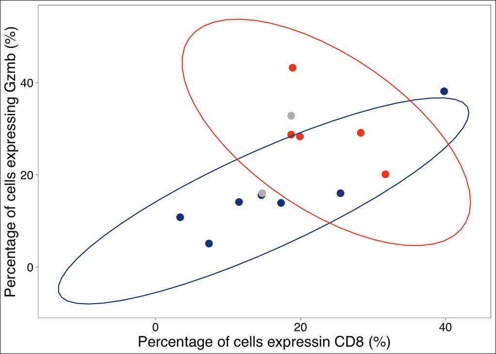

```r
ggplot(flowdataframe, aes(x=CD8, y=Gzmb,
                    color=status)) +
  geom_point(size=3) +
  theme_calc() + scale_color_manual(values = c("#1A4682", # blue
                                               "#EB522C", # orange
                                               "grey")) +
  theme(legend.position="none", axis.title = element_text(size = 15),
        panel.grid.major = element_blank(),
        panel.grid.minor = element_blank(), legend.text = element_text(size = 17),
        axis.text.x=element_text(size=12, colour = "black"),
        axis.text.y = element_text(size=12, colour = "black")) +
  stat_ellipse(level = 0.95) +
  xlab("Percentage of cells expressin CD8 (%)") +
  ylab("Percentage of cells expressing Gzmb (%)")
```

# 14 Session Info

R version 3.6.0 (2019-04-26) Platform: x86_64-apple-darwin15.6.0 (64-bit) Running under: macOS Mojave 10.14.5

Matrix products: default BLAS: /Library/Frameworks/R.framework/Versions/3.6/Resources/lib/libRblas.0.dylib LAPACK: /Library/Frameworks/R.framework/Versions/3.6/Resources/lib/libRlapack.dylib

locale: [1] en_US.UTF-8/en_US.UTF-8/en_US.UTF-8/C/en_US.UTF-8/en_US.UTF-8

attached base packages: [1] stats4 parallel stats graphics grDevices utils datasets [8] methods base

other attached packages: [1] ggpubr_0.2.1 magrittr_1.5  
[3] cowplot_0.9.4 EnsDb.Hsapiens.v86_2.99.0 [5] ensembldb_2.8.0 AnnotationFilter_1.8.0  
[7] GenomicFeatures_1.36.1 AnnotationDbi_1.46.0  
[9] Biobase_2.44.0 GenomicRanges_1.36.0  
[11] GenomeInfoDb_1.20.0 IRanges_2.18.0  
[13] S4Vectors_0.22.0 BiocGenerics_0.30.0  
[15] ggExtra_0.8 gt_0.1.0  
[17] ggrepel_0.8.1 FinCal_0.6.3  
[19] gplots_3.0.1.1 tximport_1.12.0  
[21] DT_0.6 vegan_2.5-5  
[23] lattice_0.20-38 permute_0.9-5  
[25] patchwork_0.0.1 edgeR_3.26.0  
[27] limma_3.40.0 reshape2_1.4.3  
[29] ggthemes_4.2.0 forcats_0.4.0  
[31] stringr_1.4.0 dplyr_0.8.1  
[33] purrr_0.3.2 readr_1.3.1  
[35] tidyr_0.8.3 tibble_2.1.2  
[37] ggplot2_3.1.1 tidyverse_1.2.1  
[39] knitr_1.23 rmarkdown_1.13

loaded via a namespace (and not attached): [1] colorspace_1.4-1 ggsignif_0.5.0  
[3] XVector_0.24.0 rstudioapi_0.10  
[5] bit64_0.9-7 lubridate_1.7.4  
[7] xml2_1.2.0 splines_3.6.0  
[9] jsonlite_1.6 Rsamtools_2.0.0  
[11] broom_0.5.2 cluster_2.0.9  
[13] shiny_1.3.2 compiler_3.6.0  
[15] httr_1.4.0 backports_1.1.4  
[17] assertthat_0.2.1 Matrix_1.2-17  
[19] lazyeval_0.2.2 cli_1.1.0  
[21] later_0.8.0 htmltools_0.3.6  
[23] prettyunits_1.0.2 tools_3.6.0  
[25] gtable_0.3.0 glue_1.3.1  
[27] GenomeInfoDbData_1.2.1 Rcpp_1.0.1  
[29] cellranger_1.1.0 Biostrings_2.52.0  
[31] gdata_2.18.0 nlme_3.1-140  
[33] rtracklayer_1.44.0 xfun_0.7  
[35] rvest_0.3.4 mime_0.6  
[37] miniUI_0.1.1.1 gtools_3.8.1  
[39] XML_3.99-0 MASS_7.3-51.4  
[41] zlibbioc_1.30.0 scales_1.0.0  
[43] ProtGenerics_1.16.0 hms_0.4.2  
[45] promises_1.0.1 SummarizedExperiment_1.14.0 [47] rhdf5_2.28.0 curl_3.3  
[49] yaml_2.2.0 memoise_1.1.0  
[51] sass_0.1.0.9000 biomaRt_2.40.1  
[53] stringi_1.4.3 RSQLite_2.1.1  
[55] checkmate_1.9.3 caTools_1.17.1.2  
[57] BiocParallel_1.18.0 matrixStats_0.54.0  
[59] rlang_0.3.4 pkgconfig_2.0.2  
[61] commonmark_1.7 bitops_1.0-6  
[63] evaluate_0.14 Rhdf5lib_1.6.0  
[65] labeling_0.3 GenomicAlignments_1.20.0  
[67] htmlwidgets_1.3 bit_1.1-14  
[69] tidyselect_0.2.5 plyr_1.8.4  
[71] R6_2.4.0 generics_0.0.2  
[73] DelayedArray_0.10.0 DBI_1.0.0  
[75] pillar_1.4.1 haven_2.1.0  
[77] withr_2.1.2 mgcv_1.8-28  
[79] RCurl_1.95-4.12 modelr_0.1.4  
[81] crayon_1.3.4 KernSmooth_2.23-15  
[83] progress_1.2.2 locfit_1.5-9.1  
[85] grid_3.6.0 readxl_1.3.1  
[87] blob_1.1.1 digest_0.6.19  
[89] xtable_1.8-4 httpuv_1.5.1  
[91] munsell_0.5.0